# DBA3803/DSC3216 Group Project

Group 16

21 October 2019

**DBA3803/DSC3216 Group Project**

Group 16:

Goh Chin Yong, A0139748M Lim Wei Yang, A0167212M Ng Joo Kang, A0167730A

**Business Problem**

We are a budding real-estate company that is looking to enter the Iowa real-estate market. We are currently looking to obtain a sizeable portfolio of houses, but we are not sure of what is the right price to quote when sending our agents to buy houses. As such, we are in the process of coming up with a model which is able to predict the prices as close as the actual sale prices in which clients will be willing to sell them for. We’ve collected data on 1460 prior housing sales in the neighbourhood for the past few years, and we’ll be conducting Analysis and Regression modelling on them in order to more accurately quote our clients’ houses.

**Data Source**

We’ll be using the dataset provided from this Kaggle Data Competition - ‘House Prices - Advanced Regression Techniques’.

The url is “https://www.kaggle.com/c/house-prices-advanced-regression-techniques/overview”.

We’ll only be utilising the “train.csv” from the Kaggle dataset, which contains 1460 rows of 81 columns. We’ll be referencing to “data_descriptions.txt” which provides an in-depth description and explanation into each of the 81 variables listed in the dataset.

**Objective**

The objective of our project will be to minimise expected loss, using the prediction model that we have chosen at the end of our data analysis. We’ll do this through a Scenario Testing at the end.

**Managerial Decisions**

Stakeholders can apply our prediction model on future house sales in the town of Iowa, and they can make use of the results to more effectively price houses.

The prediction model is customisable - stakeholders will be able to customise it to other towns with similar provided inputs. Thus, the model will be able to be applied to other towns and neighbourhoods with a similar accuracy.

**Our Group’s Approach**

The report will be broken down into 11 parts:

1. Initialisation

Loading required libraries and reading the data, as well as an initial look into the structure of the dataframe.

2. Data Cleaning

While understanding and analysing the dataframe, we’ll be cleaning the dataset as well. We’ll be removing unneeded variables, cleaning up NA values, categorising the variables properly, etc.

3. Data Reshaping

After the initial data cleaning and exploration in Section 2), we’ll be deep-diving into the more important variables in this section. We’ll be reshaping the data according to explored and observed relationships, while also constructing new, more useful variables.

7. Prediction Modelling

And finally, we’ll be creating our various models in this section. We’ll be implementing 4 models:

1. Multi-regression
2. Regression Tree
3. Random Forest
4. Extreme Gradient Boosting (XGBoost)
8. Model Evaluations

We’ll evaluate all 4 models based on their accuracy (R-squared), and error rate (Root Mean Squared Logarithmic Error).

9. Scenario Testing

After evaluating the models, we’ll then apply them to our business problem through a scenario testing analysis, calculating expected losses and comparing the losses between each model.

10. Limitations

We discuss the limitations of both our models and our dataset in this section.

11. Conclusion

And finally, we conclude our report in this section.

**Project Analysis Code**

## 1. Initialisation

### 1.1 Loading libraries

```r
library(dplyr)
library(ggplot2)
library(lubridate)
library(party)
library(randomForest)
library(knitr)
library(rminer)
library(reshape2)
library(MLmetrics)
library(tidyr)
library(scales)
library(corrplot)
library(gridExtra)
library(moments)
library(caret)
library(xgboost)
library(gbm)
```

### 1.2 Reading data

An initial look into the structure of the dataframe.

```r
df <- read.csv("train.csv")
str(df)
```

```
## 'data.frame':    1460 obs. of  81 variables:
##  $ Id           : int  1 2 3 4 5 6 7 8 9 10 ...
##  $ MSSubClass   : int  60 20 60 70 60 50 20 60 50 190 ...
##  $ MSZoning     : Factor w/ 5 levels "C (all)","FV",..: 4 4 4 4 4 4 4 4 5 4 ...
##  $ LotFrontage  : int  65 80 68 60 84 85 75 NA 51 50 ...
##  $ LotArea      : int  8450 9600 11250 9550 14260 14115 10084 10382 6120 7420 ...
##  $ Street       : Factor w/ 2 levels "Grvl","Pave": 2 2 2 2 2 2 2 2 2 2 ...
##  $ Alley        : Factor w/ 2 levels "Grvl","Pave": NA NA NA NA NA NA NA NA NA NA ...
##  $ LotShape     : Factor w/ 4 levels "IR1","IR2","IR3",..: 4 4 1 1 1 1 4 1 4 4 ...
##  $ LandContour  : Factor w/ 4 levels "Bnk","HLS","Low",..: 4 4 4 4 4 4 4 4 4 4 ...
##  $ Utilities    : Factor w/ 2 levels "AllPub","NoSeWa": 1 1 1 1 1 1 1 1 1 1 ...
##  $ LotConfig    : Factor w/ 5 levels "Corner","CulDSac",..: 5 3 5 1 3 5 5 1 5 1 ...
##  $ LandSlope    : Factor w/ 3 levels "Gtl","Mod","Sev": 1 1 1 1 1 1 1 1 1 1 ...
##  $ Neighborhood : Factor w/ 25 levels "Blmngtn","Blueste",..: 6 25 6 7 14 12 21 17 18 4 ...
##  $ Condition1   : Factor w/ 9 levels "Artery","Feedr",..: 3 2 3 3 3 3 3 5 1 1 ...
```

[output cut: 67 more lines]

We have a total of 81 variables, including the Target Variable SalePrice.

## 2. Data Cleaning

### 2.1 Removing the ID variable as rows are already numbered

The ID variable may affect our prediction models’ predictions.

```r
df$Id <- NULL
```

### 2.2 Dealing with categorical variables incorrectly formatted as numeric

We found that there is one variable, MSSubClass, that is formatted wrongly as numeric instead of categorical. From data_descriptions, we see that MSSubClass represents the ID of the type of housing, with each ID representing a different type of housing, such as ‘20’ representing a housing that is a 1-storey building, built after 1946.

We will convert this variable into an unordered factor to more correctly reflect this classification.

```r
df[,'MSSubClass'] <- df[,'MSSubClass'] %>% as.factor()
df['MSSubClass'] %>% summary
```

```
##    MSSubClass
##  20     :536
##  60     :299
##  50     :144
##  120    : 87
##  30     : 69
##  160    : 63
##  (Other):262
```

### 2.3 Dealing with categorical factors

Let’s take a closer look at the categorical factors.

```r
df %>% select_if(is.factor) %>% summary()
```

```
##    MSSubClass     MSZoning     Street      Alley      LotShape
##  20     :536   C (all):  10   Grvl:   6   Grvl:  50   IR1:484
##  60     :299   FV     :  65   Pave:1454   Pave:  41   IR2: 41
##  50     :144   RH     :  16               NA's:1369   IR3: 10
##  120    : 87   RL     :1151                           Reg:925
##  30     : 69   RM     : 218
##  160    : 63
##  (Other):262
##  LandContour  Utilities      LotConfig    LandSlope   Neighborhood
##  Bnk:  63    AllPub:1459   Corner : 263   Gtl:1382   NAmes  :225
##  HLS:  50    NoSeWa:   1   CulDSac:  94   Mod:  65   CollgCr:150
##  Low:  36                  FR2    :  47   Sev:  13   OldTown:113
##  Lvl:1311                  FR3    :   4              Edwards:100
##                            Inside :1052              Somerst: 86
##                                                      Gilbert: 79
##                                                      (Other):707
##    Condition1     Condition2     BldgType      HouseStyle    RoofStyle
##  Norm   :1260   Norm   :1445   1Fam  :1220   1Story :726   Flat   :  13
##  Feedr  :  81   Feedr  :   6   2fmCon:  31   2Story :445   Gable  :1141
##  Artery :  48   Artery :   2   Duplex:  52   1.5Fin :154   Gambrel:  11
##  RRAn   :  26   PosN   :   2   Twnhs :  43   SLvl   : 65   Hip    : 286
##  PosN   :  19   RRNn   :   2   TwnhsE: 114   SFoyer : 37   Mansard:   7
##  RRAe   :  11   PosA   :   1                 1.5Unf : 14   Shed   :   2
##  (Other):  15   (Other):   2                 (Other): 19
##     RoofMatl     Exterior1st   Exterior2nd    MasVnrType  ExterQual
##  CompShg:1434   VinylSd:515   VinylSd:504   BrkCmn : 15   Ex: 52
##  Tar&Grv:  11   HdBoard:222   MetalSd:214   BrkFace:445   Fa: 14
##  WdShngl:   6   MetalSd:220   HdBoard:207   None   :864   Gd:488
##  WdShake:   5   Wd Sdng:206   Wd Sdng:197   Stone  :128   TA:906
##  ClyTile:   1   Plywood:108   Plywood:142   NA's   :  8
##  Membran:   1   CemntBd: 61   CmentBd: 60
##  (Other):   2   (Other):128   (Other):136
##  ExterCond  Foundation  BsmtQual   BsmtCond    BsmtExposure BsmtFinType1
##  Ex:   3   BrkTil:146   Ex  :121   Fa  :  45   Av  :221     ALQ :220
##  Fa:  28   CBlock:634   Fa  : 35   Gd  :  65   Gd  :134     BLQ :148
##  Gd: 146   PConc :647   Gd  :618   Po  :   2   Mn  :114     GLQ :418
##  Po:   1   Slab  : 24   TA  :649   TA  :1311   No  :953     LwQ : 74
##  TA:1282   Stone :  6   NA's: 37   NA's:  37   NA's: 38     Rec :133
##            Wood  :  3                                       Unf :430
##                                                             NA's: 37
```

[output cut: 17 more lines]

```
##  Ex  :   2   N:  90     Ex  :   2   GdPrv:  59   Gar2:   2
##  Fa  :  35   P:  30     Fa  :   2   GdWo :  54   Othr:   2
##  Gd  :   9   Y:1340     Gd  :   3   MnPrv: 157   Shed:  49
##  Po  :   7              NA's:1453   MnWw :  11   TenC:   1
##  TA  :1326                          NA's :1179   NA's:1406
##  NA's:  81
##
##     SaleType    SaleCondition
##  WD     :1267   Abnorml: 101
##  New    : 122   AdjLand:   4
##  COD    :  43   Alloca :  12
##  ConLD  :   9   Family :  20
##  ConLI  :   5   Normal :1198
##  ConLw  :   5   Partial: 125
##  (Other):   9
```

All of the categorical variables describe a specific feature of the house with varying number of levels (i.e. PoolQC describes the quality of the house’s pool).

However, some of these variables contain NA’s, which indicate that that particular categorical variable does not apply to the house in question.

Taking another look at data_description.txt, we see that ‘NA’ for most of the variables mean that the house does not have that particular feature. For example, PoolQC indicates whether the house’s pool quality is negative, or positve. NA’s indicate that the house doesn’t have a pool, and hence there is no pool quality.

Another interesting observation we found was that the Utilities variable only has two factors, and there’s only one observation on NoSeWa, with the other 1459 as AllPub. This thus tells us that the Utilities variable would not be as useful as a predictor variable, and consequently, it is acceptable to get rid of it.

### 2.4 Removing the Utilities variable

```r
df$Utilities <- NULL
```

Let’s take a closer look at the categorical variables with NA so we can better ascertain the course of action to take for the NA values.

### 2.5 Picking categorical variables with NA

```r
# Picking out the categorical variables
catVars <- df[which(sapply(df, is.factor))]
ncol(catVars) # We have 43 categorical variables
```

```
## [1] 43
```

```r
sort(colSums(sapply(catVars[which(colSums((is.na(catVars))) > 0)], is.na)), decreasing = TRUE)
```

```
##       PoolQC  MiscFeature        Alley        Fence  FireplaceQu
##         1453         1406         1369         1179          690
##   GarageType GarageFinish   GarageQual   GarageCond BsmtExposure
##           81           81           81           81           38
## BsmtFinType2     BsmtQual     BsmtCond BsmtFinType1   MasVnrType
##           38           37           37           37            8
##   Electrical
##            1
```

We have 43 different categorical variables.

Out of the 43 different categorical variables, 16 of them has NA values.

For each of the 16 variables, we refer to data_descriptions for a better understanding of what NA means.

Out of the 16 variables, only MasVnrType and Electrical has no explanation for what ‘NA’ stands for, whereas for the other 14, ‘NA’ means that the house does not have that particular feature. Hence, they can be easily fixed by changing ‘NA’ to ‘None’.

Let’s take a closer look at MasVnrType and Electrical, and fix their NA values, before fixing the other 14 variables.

### 2.6 A closer look at MasVnrType

MasVnrType describes the type of veneer area, if any. There are 5 factors, with None as one of them.

A summary tells us that there are only 8 NA’s, and there are actually 864 existing variables with no veneer area.

```r
summary(df$MasVnrType)
```

```
##  BrkCmn BrkFace    None   Stone    NA's
##      15     445     864     128       8
```

Looking closer at the rows with NA tells us that their corresponding MasVnrArea is NA as well. This indicates that we can safely change the ‘NA’s to ’None’. We’ll also change the NA’s in MasVnrArea to 0, since if the house does not have a veneer area, the area should be 0.

```r
df[is.na(df$MasVnrType), c("MasVnrType", 'MasVnrArea')]
```

```
##      MasVnrType MasVnrArea
## 235        <NA>         NA
## 530        <NA>         NA
## 651        <NA>         NA
## 937        <NA>         NA
## 974        <NA>         NA
## 978        <NA>         NA
## 1244       <NA>         NA
## 1279       <NA>         NA
```

```r
df$MasVnrType[is.na(df$MasVnrType)] <- 'None'
df$MasVnrArea[is.na(df$MasVnrArea)] <-  0
```

### 2.7 A closer look at Electrical

Since there is only 1 NA value, and it is quite unorthodox for a house to be sold without any electrical system at all, we’ll impute the NA value with the mode, which from looking at the summary, is SBrkr.

```r
summary(df$Electrical)
```

```
## FuseA FuseF FuseP   Mix SBrkr  NA's
##    94    27     3     1  1334     1
```

```r
df$Electrical[is.na(df$Electrical)] <- 'SBrkr'
```

Now that we’ve fixed MasVnrType and Electrical, we’ll move on to fixing the other 14 categorical variables.

### 2.8 Fixing NA in categorical variables

```r
  # Replace all NAs in factors with "None"
  for (column in names(which(colSums(is.na(catVars)) > 0))) {
    df[,column] <- df[,column] %>% as.character() %>% replace_na("None") %>% as.factor()
  }

  df %>% select_if(is.factor) %>% summary()
```

```
##    MSSubClass     MSZoning     Street      Alley      LotShape
##  20     :536   C (all):  10   Grvl:   6   Grvl:  50   IR1:484
##  60     :299   FV     :  65   Pave:1454   None:1369   IR2: 41
##  50     :144   RH     :  16               Pave:  41   IR3: 10
##  120    : 87   RL     :1151                           Reg:925
##  30     : 69   RM     : 218
##  160    : 63
##  (Other):262
##  LandContour   LotConfig    LandSlope   Neighborhood   Condition1
##  Bnk:  63    Corner : 263   Gtl:1382   NAmes  :225   Norm   :1260
##  HLS:  50    CulDSac:  94   Mod:  65   CollgCr:150   Feedr  :  81
##  Low:  36    FR2    :  47   Sev:  13   OldTown:113   Artery :  48
##  Lvl:1311    FR3    :   4              Edwards:100   RRAn   :  26
##              Inside :1052              Somerst: 86   PosN   :  19
##                                        Gilbert: 79   RRAe   :  11
##                                        (Other):707   (Other):  15
##    Condition2     BldgType      HouseStyle    RoofStyle       RoofMatl
##  Norm   :1445   1Fam  :1220   1Story :726   Flat   :  13   CompShg:1434
##  Feedr  :   6   2fmCon:  31   2Story :445   Gable  :1141   Tar&Grv:  11
##  Artery :   2   Duplex:  52   1.5Fin :154   Gambrel:  11   WdShngl:   6
##  PosN   :   2   Twnhs :  43   SLvl   : 65   Hip    : 286   WdShake:   5
##  RRNn   :   2   TwnhsE: 114   SFoyer : 37   Mansard:   7   ClyTile:   1
##  PosA   :   1                 1.5Unf : 14   Shed   :   2   Membran:   1
##  (Other):   2                 (Other): 19                  (Other):   2
##   Exterior1st   Exterior2nd    MasVnrType  ExterQual ExterCond
##  VinylSd:515   VinylSd:504   BrkCmn : 15   Ex: 52    Ex:   3
##  HdBoard:222   MetalSd:214   BrkFace:445   Fa: 14    Fa:  28
##  MetalSd:220   HdBoard:207   None   :872   Gd:488    Gd: 146
##  Wd Sdng:206   Wd Sdng:197   Stone  :128   TA:906    Po:   1
##  Plywood:108   Plywood:142                           TA:1282
##  CemntBd: 61   CmentBd: 60
##  (Other):128   (Other):136
##   Foundation  BsmtQual   BsmtCond    BsmtExposure BsmtFinType1
##  BrkTil:146   Ex  :121   Fa  :  45   Av  :221     ALQ :220
##  CBlock:634   Fa  : 35   Gd  :  65   Gd  :134     BLQ :148
##  PConc :647   Gd  :618   None:  37   Mn  :114     GLQ :418
##  Slab  : 24   None: 37   Po  :   2   No  :953     LwQ : 74
##  Stone :  6   TA  :649   TA  :1311   None: 38     None: 37
##  Wood  :  3                                       Rec :133
##                                                   Unf :430
```

[output cut: 17 more lines]

```
##  Ex  :   2   N:  90     Ex  :   2   GdPrv:  59   Gar2:   2
##  Fa  :  35   P:  30     Fa  :   2   GdWo :  54   None:1406
##  Gd  :   9   Y:1340     Gd  :   3   MnPrv: 157   Othr:   2
##  None:  81              None:1453   MnWw :  11   Shed:  49
##  Po  :   7                          None :1179   TenC:   1
##  TA  :1326
##
##     SaleType    SaleCondition
##  WD     :1267   Abnorml: 101
##  New    : 122   AdjLand:   4
##  COD    :  43   Alloca :  12
##  ConLD  :   9   Family :  20
##  ConLI  :   5   Normal :1198
##  ConLw  :   5   Partial: 125
##  (Other):   9
```

### 2.9 Dealing with ordered categorical factors

Analysing data_descriptions further, We have identified 15 factors which are meant to be ordered as per below:

```r
  # We need to order them
  # These categorical factors are meant to be ordered
  df[c('ExterQual','ExterCond','BsmtQual', 'BsmtCond', 'BsmtExposure', 'BsmtFinType1', 'BsmtFinType2', 'HeatingQC',
       'KitchenQual', 'Functional', 'FireplaceQu', 'GarageFinish', 'GarageQual', 'GarageCond',
       'PoolQC')] %>% summary
```

```
##  ExterQual ExterCond BsmtQual   BsmtCond    BsmtExposure BsmtFinType1
##  Ex: 52    Ex:   3   Ex  :121   Fa  :  45   Av  :221     ALQ :220
##  Fa: 14    Fa:  28   Fa  : 35   Gd  :  65   Gd  :134     BLQ :148
##  Gd:488    Gd: 146   Gd  :618   None:  37   Mn  :114     GLQ :418
##  TA:906    Po:   1   None: 37   Po  :   2   No  :953     LwQ : 74
##            TA:1282   TA  :649   TA  :1311   None: 38     None: 37
##                                                          Rec :133
##                                                          Unf :430
##  BsmtFinType2 HeatingQC KitchenQual Functional  FireplaceQu GarageFinish
##  ALQ :  19    Ex:741    Ex:100      Maj1:  14   Ex  : 24    Fin :352
##  BLQ :  33    Fa: 49    Fa: 39      Maj2:   5   Fa  : 33    None: 81
##  GLQ :  14    Gd:241    Gd:586      Min1:  31   Gd  :380    RFn :422
##  LwQ :  46    Po:  1    TA:735      Min2:  34   None:690    Unf :605
##  None:  38    TA:428                Mod :  15   Po  : 20
##  Rec :  54                          Sev :   1   TA  :313
##  Unf :1256                          Typ :1360
##  GarageQual  GarageCond   PoolQC
##  Ex  :   3   Ex  :   2   Ex  :   2
##  Fa  :  48   Fa  :  35   Fa  :   2
##  Gd  :  14   Gd  :   9   Gd  :   3
##  None:  81   None:  81   None:1453
##  Po  :   3   Po  :   7
##  TA  :1311   TA  :1326
##
```

We will order and arrange them manually according to data_description.txt.

```r
  # Convert categorical factors into ordered factors for the above columns
  df[,'ExterQual'] <- df[,'ExterQual'] %>% ordered(levels = c('Po', 'Fa', 'TA', 'Gd', 'Ex'))
  df[,'ExterCond'] <- df[,'ExterCond'] %>% ordered(levels = c('Po', 'Fa', 'TA', 'Gd', 'Ex'))

  # For basement (5 ordered categorical columns), NAs represent no basement, we will convert them into "None" for these factors
  df[,'BsmtQual'] <- df[,'BsmtQual'] %>% ordered(levels = c('None', 'Po', 'Fa', 'TA', 'Gd', 'Ex'))
  df[,'BsmtCond'] <- df[,'BsmtCond'] %>% ordered(levels = c('None', 'Po', 'Fa', 'TA', 'Gd', 'Ex'))
  df[,'BsmtExposure'] <- df[,'BsmtExposure'] %>% ordered(levels = c('None', 'No', 'Mn', 'Av', 'Gd'))
  df[,'BsmtFinType1'] <- df[,'BsmtFinType1'] %>% ordered(levels = c('None', 'Unf', 'LwQ', 'Rec', 'BLQ', 'ALQ', 'GLQ'))
  df[,'BsmtFinType2'] <- df[,'BsmtFinType2'] %>% ordered(levels = c('None', 'Unf', 'LwQ', 'Rec', 'BLQ', 'ALQ', 'GLQ'))


  df[,'HeatingQC'] <- df[,'HeatingQC'] %>% ordered(levels = c('Po', 'Fa', 'TA', 'Gd', 'Ex'))
  df[,'KitchenQual'] <- df[,'KitchenQual'] %>% ordered(levels = c('Po', 'Fa', 'TA', 'Gd', 'Ex'))
  df[,'Functional'] <- df[,'Functional'] %>% ordered(levels = c('Sal', 'Sev', 'Maj2', 'Maj1', 'Mod', 'Min2', 'Min1', 'Typ'))

  # For fireplace (1 ordered categorical column), no fireplace means NA, we will replace with "None" and order them as worst
  df[,'FireplaceQu'] <- df[,'FireplaceQu'] %>% ordered(levels = c('None', 'Po', 'Fa', 'TA', 'Gd', 'Ex'))

  # For garage (3 ordered categorical columns), no garage means NA, replace with "None" as well
  df[,'GarageFinish'] <- df[,'GarageFinish'] %>% ordered(levels = c('None', 'Unf', 'RFn', 'Fin'))
  df[,'GarageQual'] <- df[,'GarageQual'] %>% ordered(levels = c('None', 'Po', 'Fa', 'TA', 'Gd', 'Ex'))
  df[,'GarageCond'] <- df[,'GarageCond'] %>% ordered(levels = c('None', 'Po', 'Fa', 'TA', 'Gd', 'Ex'))

  # For pool (1 ordered categorical column), no pool means NA, replace with "None" as well
  df[,'PoolQC'] <- df[,'PoolQC'] %>% ordered(levels = c('None', 'Fa', 'TA', 'Gd', 'Ex'))

  # Check for any more NAs
  df[c('ExterQual','ExterCond','BsmtQual', 'BsmtCond', 'BsmtExposure', 'BsmtFinType1', 'BsmtFinType2', 'HeatingQC',
       'KitchenQual', 'Functional', 'FireplaceQu', 'GarageFinish', 'GarageQual', 'GarageCond',
       'PoolQC')] %>% summary
```

```
##  ExterQual ExterCond BsmtQual   BsmtCond    BsmtExposure BsmtFinType1
##  Po:  0    Po:   1   None: 37   None:  37   None: 38     None: 37
##  Fa: 14    Fa:  28   Po  :  0   Po  :   2   No  :953     Unf :430
##  TA:906    TA:1282   Fa  : 35   Fa  :  45   Mn  :114     LwQ : 74
##  Gd:488    Gd: 146   TA  :649   TA  :1311   Av  :221     Rec :133
##  Ex: 52    Ex:   3   Gd  :618   Gd  :  65   Gd  :134     BLQ :148
##                      Ex  :121   Ex  :   0                ALQ :220
##                                                          GLQ :418
##  BsmtFinType2 HeatingQC KitchenQual   Functional   FireplaceQu
##  None:  38    Po:  1    Po:  0      Typ    :1360   None:690
##  Unf :1256    Fa: 49    Fa: 39      Min2   :  34   Po  : 20
##  LwQ :  46    TA:428    TA:735      Min1   :  31   Fa  : 33
##  Rec :  54    Gd:241    Gd:586      Mod    :  15   TA  :313
##  BLQ :  33    Ex:741    Ex:100      Maj1   :  14   Gd  :380
##  ALQ :  19                          Maj2   :   5   Ex  : 24
##  GLQ :  14                          (Other):   1
##  GarageFinish GarageQual  GarageCond   PoolQC
##  None: 81     None:  81   None:  81   None:1453
##  Unf :605     Po  :   3   Po  :   7   Fa  :   2
##  RFn :422     Fa  :  48   Fa  :  35   TA  :   0
##  Fin :352     TA  :1311   TA  :1326   Gd  :   3
##               Gd  :  14   Gd  :   9   Ex  :   2
##               Ex  :   3   Ex  :   2
##
```

Now that our categorical variables are factored and ordered properly, and the NA’s are cleaned, we’ll now move on to the numerical variables.

### 2.10 Converting YrSold and MoSold into factors

Although these 2 variables are numerical variables, but it makes sense for them to be factored, as they can tell us the trend over years and months.

```r
unique(df$YrSold) # Tells us that there are only 5 levels of YrSold
```

```
## [1] 2008 2007 2006 2009 2010
```

```r
unique(df$MoSold) # As we expected, 12 levels of MoSold (12 months)
```

```
##  [1]  2  5  9 12 10  8 11  4  1  7  3  6
```

```r
df$YrSold <- as.factor(df$YrSold)
df$MoSold <- as.factor(df$MoSold)
```

### 2.11 Analysing numerical variables

We’ll take a closer look at the numerical variables to see if there’s any cleaning or modifications we need to do.

```r
df %>% select_if(is.numeric) %>% summary
```

```
##   LotFrontage        LotArea        OverallQual      OverallCond
##  Min.   : 21.00   Min.   :  1300   Min.   : 1.000   Min.   :1.000
##  1st Qu.: 59.00   1st Qu.:  7554   1st Qu.: 5.000   1st Qu.:5.000
##  Median : 69.00   Median :  9478   Median : 6.000   Median :5.000
##  Mean   : 70.05   Mean   : 10517   Mean   : 6.099   Mean   :5.575
##  3rd Qu.: 80.00   3rd Qu.: 11602   3rd Qu.: 7.000   3rd Qu.:6.000
##  Max.   :313.00   Max.   :215245   Max.   :10.000   Max.   :9.000
##  NA's   :259
##    YearBuilt     YearRemodAdd    MasVnrArea       BsmtFinSF1
##  Min.   :1872   Min.   :1950   Min.   :   0.0   Min.   :   0.0
##  1st Qu.:1954   1st Qu.:1967   1st Qu.:   0.0   1st Qu.:   0.0
##  Median :1973   Median :1994   Median :   0.0   Median : 383.5
##  Mean   :1971   Mean   :1985   Mean   : 103.1   Mean   : 443.6
##  3rd Qu.:2000   3rd Qu.:2004   3rd Qu.: 164.2   3rd Qu.: 712.2
##  Max.   :2010   Max.   :2010   Max.   :1600.0   Max.   :5644.0
##
##    BsmtFinSF2        BsmtUnfSF       TotalBsmtSF       X1stFlrSF
##  Min.   :   0.00   Min.   :   0.0   Min.   :   0.0   Min.   : 334
##  1st Qu.:   0.00   1st Qu.: 223.0   1st Qu.: 795.8   1st Qu.: 882
##  Median :   0.00   Median : 477.5   Median : 991.5   Median :1087
##  Mean   :  46.55   Mean   : 567.2   Mean   :1057.4   Mean   :1163
##  3rd Qu.:   0.00   3rd Qu.: 808.0   3rd Qu.:1298.2   3rd Qu.:1391
##  Max.   :1474.00   Max.   :2336.0   Max.   :6110.0   Max.   :4692
##
##    X2ndFlrSF     LowQualFinSF       GrLivArea     BsmtFullBath
##  Min.   :   0   Min.   :  0.000   Min.   : 334   Min.   :0.0000
##  1st Qu.:   0   1st Qu.:  0.000   1st Qu.:1130   1st Qu.:0.0000
##  Median :   0   Median :  0.000   Median :1464   Median :0.0000
##  Mean   : 347   Mean   :  5.845   Mean   :1515   Mean   :0.4253
##  3rd Qu.: 728   3rd Qu.:  0.000   3rd Qu.:1777   3rd Qu.:1.0000
##  Max.   :2065   Max.   :572.000   Max.   :5642   Max.   :3.0000
##
##   BsmtHalfBath        FullBath        HalfBath       BedroomAbvGr
##  Min.   :0.00000   Min.   :0.000   Min.   :0.0000   Min.   :0.000
##  1st Qu.:0.00000   1st Qu.:1.000   1st Qu.:0.0000   1st Qu.:2.000
##  Median :0.00000   Median :2.000   Median :0.0000   Median :3.000
##  Mean   :0.05753   Mean   :1.565   Mean   :0.3829   Mean   :2.866
##  3rd Qu.:0.00000   3rd Qu.:2.000   3rd Qu.:1.0000   3rd Qu.:3.000
##  Max.   :2.00000   Max.   :3.000   Max.   :2.0000   Max.   :8.000
##
```

[output cut: 17 more lines]

```
##  Min.   :  0.00   Min.   :  0.00   Min.   :  0.00   Min.   :  0.000
##  1st Qu.:  0.00   1st Qu.:  0.00   1st Qu.:  0.00   1st Qu.:  0.000
##  Median :  0.00   Median :  0.00   Median :  0.00   Median :  0.000
##  Mean   : 21.95   Mean   :  3.41   Mean   : 15.06   Mean   :  2.759
##  3rd Qu.:  0.00   3rd Qu.:  0.00   3rd Qu.:  0.00   3rd Qu.:  0.000
##  Max.   :552.00   Max.   :508.00   Max.   :480.00   Max.   :738.000
##
##     MiscVal           SalePrice
##  Min.   :    0.00   Min.   : 34900
##  1st Qu.:    0.00   1st Qu.:129975
##  Median :    0.00   Median :163000
##  Mean   :   43.49   Mean   :180921
##  3rd Qu.:    0.00   3rd Qu.:214000
##  Max.   :15500.00   Max.   :755000
##
```

We see that there are only 2 variables with NA’s - LotFrontage and GarageYrBlt. For LotFrontage, an NA indicates that there is no street connected to the property, hence an NA makes sense. For GarageYrBlt, an NA indicates that there is no Garage built, hence an NA makes sense. Although the NA’s don’t look very nice, but since they make sense in the data, we won’t be fixing them.

### 2.12 Summary of final cleaned data

```r
# 1460 final rows
df %>% nrow()
```

```
## [1] 1460
```

```r
df %>% summary
```

```
##    MSSubClass     MSZoning     LotFrontage        LotArea
##  20     :536   C (all):  10   Min.   : 21.00   Min.   :  1300
##  60     :299   FV     :  65   1st Qu.: 59.00   1st Qu.:  7554
##  50     :144   RH     :  16   Median : 69.00   Median :  9478
##  120    : 87   RL     :1151   Mean   : 70.05   Mean   : 10517
##  30     : 69   RM     : 218   3rd Qu.: 80.00   3rd Qu.: 11602
##  160    : 63                  Max.   :313.00   Max.   :215245
##  (Other):262                  NA's   :259
##   Street      Alley      LotShape  LandContour   LotConfig    LandSlope
##  Grvl:   6   Grvl:  50   IR1:484   Bnk:  63    Corner : 263   Gtl:1382
##  Pave:1454   None:1369   IR2: 41   HLS:  50    CulDSac:  94   Mod:  65
##              Pave:  41   IR3: 10   Low:  36    FR2    :  47   Sev:  13
##                          Reg:925   Lvl:1311    FR3    :   4
##                                                Inside :1052
##
##
##   Neighborhood   Condition1     Condition2     BldgType      HouseStyle
##  NAmes  :225   Norm   :1260   Norm   :1445   1Fam  :1220   1Story :726
##  CollgCr:150   Feedr  :  81   Feedr  :   6   2fmCon:  31   2Story :445
##  OldTown:113   Artery :  48   Artery :   2   Duplex:  52   1.5Fin :154
##  Edwards:100   RRAn   :  26   PosN   :   2   Twnhs :  43   SLvl   : 65
##  Somerst: 86   PosN   :  19   RRNn   :   2   TwnhsE: 114   SFoyer : 37
##  Gilbert: 79   RRAe   :  11   PosA   :   1                 1.5Unf : 14
##  (Other):707   (Other):  15   (Other):   2                 (Other): 19
##   OverallQual      OverallCond      YearBuilt     YearRemodAdd
##  Min.   : 1.000   Min.   :1.000   Min.   :1872   Min.   :1950
##  1st Qu.: 5.000   1st Qu.:5.000   1st Qu.:1954   1st Qu.:1967
##  Median : 6.000   Median :5.000   Median :1973   Median :1994
##  Mean   : 6.099   Mean   :5.575   Mean   :1971   Mean   :1985
##  3rd Qu.: 7.000   3rd Qu.:6.000   3rd Qu.:2000   3rd Qu.:2004
##  Max.   :10.000   Max.   :9.000   Max.   :2010   Max.   :2010
##
##    RoofStyle       RoofMatl     Exterior1st   Exterior2nd    MasVnrType
##  Flat   :  13   CompShg:1434   VinylSd:515   VinylSd:504   BrkCmn : 15
##  Gable  :1141   Tar&Grv:  11   HdBoard:222   MetalSd:214   BrkFace:445
##  Gambrel:  11   WdShngl:   6   MetalSd:220   HdBoard:207   None   :872
##  Hip    : 286   WdShake:   5   Wd Sdng:206   Wd Sdng:197   Stone  :128
##  Mansard:   7   ClyTile:   1   Plywood:108   Plywood:142
##  Shed   :   2   Membran:   1   CemntBd: 61   CmentBd: 60
##                 (Other):   2   (Other):128   (Other):136
```

[output cut: 81 more lines]

```
##  GdPrv:  59   Gar2:   2   Min.   :    0.00   6      :253   2006:314
##  GdWo :  54   None:1406   1st Qu.:    0.00   7      :234   2007:329
##  MnPrv: 157   Othr:   2   Median :    0.00   5      :204   2008:304
##  MnWw :  11   Shed:  49   Mean   :   43.49   4      :141   2009:338
##  None :1179   TenC:   1   3rd Qu.:    0.00   8      :122   2010:175
##                           Max.   :15500.00   3      :106
##                                              (Other):400
##     SaleType    SaleCondition    SalePrice
##  WD     :1267   Abnorml: 101   Min.   : 34900
##  New    : 122   AdjLand:   4   1st Qu.:129975
##  COD    :  43   Alloca :  12   Median :163000
##  ConLD  :   9   Family :  20   Mean   :180921
##  ConLI  :   5   Normal :1198   3rd Qu.:214000
##  ConLw  :   5   Partial: 125   Max.   :755000
##  (Other):   9
```

## 3. Data Reshaping

In this part, we will introduce new variables which are able to potentially tell us more about each house.

### 3.1 Age and isRemodelled

Given the YrSold, YearBuilt and YearRemodAdd variables, we can reshape the data to tell us more about the Age of the house, and whether it has been through remodelling.

YearBuilt: Original construction date  
YearRemodAdd: Remodel date (same as YearBuilt if there are no remodeling or additions)

```r
# Have to convert the factor back to numeric
df$Age <- df$YrSold %>% as.character() %>% as.numeric() - df$YearBuilt %>% as.character() %>% as.numeric()
df$isRemodelled <- ifelse(df$YearBuilt == df$YearRemodAdd, 0, 1)
```

### 3.2 Area Analysis

As can be seen below, there are 17 numerical area variables all formatted by square feet. The purpose of this portion is to break down the variables which will be useful to us and transform them into more meaningful variables.

```r
areaCol <- c("LotArea",
             "BsmtFinSF1", "BsmtFinSF2", "BsmtUnfSF", "TotalBsmtSF",
             "X1stFlrSF", "X2ndFlrSF", "GrLivArea",
             "LowQualFinSF", "GarageArea",
             "WoodDeckSF", "OpenPorchSF", "EnclosedPorch", "3SsnPorch", "ScreenPorch",
             "PoolArea", "MasVnrArea")
areaCol
```

```
##  [1] "LotArea"       "BsmtFinSF1"    "BsmtFinSF2"    "BsmtUnfSF"
##  [5] "TotalBsmtSF"   "X1stFlrSF"     "X2ndFlrSF"     "GrLivArea"
##  [9] "LowQualFinSF"  "GarageArea"    "WoodDeckSF"    "OpenPorchSF"
## [13] "EnclosedPorch" "3SsnPorch"     "ScreenPorch"   "PoolArea"
## [17] "MasVnrArea"
```

#### 3.2.1 GrLivingArea

We’ll first take a look at GrLivingArea. Referring to data_description.txt, it translates to ‘Above Ground Living Area’ in square feet.

As can be seen below, GrLivArea is simply the sum of X1stFlrSF and X2ndFlrSF, which makes sense.

```r
df %>% select(c("X1stFlrSF", "X2ndFlrSF", "GrLivArea")) %>% head(10)
```

```
##    X1stFlrSF X2ndFlrSF GrLivArea
## 1        856       854      1710
## 2       1262         0      1262
## 3        920       866      1786
## 4        961       756      1717
## 5       1145      1053      2198
## 6        796       566      1362
## 7       1694         0      1694
## 8       1107       983      2090
## 9       1022       752      1774
## 10      1077         0      1077
```

Therefore, we should use GrLivArea and not X1stFlrSF or X2ndFlrSF for regression to prevent correlations.

We can introduce a boolean variable (has2ndFlr) to indicate if a house has a 2nd story or not for consideration in regression.

```r
df$has2ndFlr <- ifelse(df$X2ndFlrSF > 0, 1, 0)
```

#### 3.2.2 LowQualFinSF

LowQualFinSF: Low quality finished square feet (all floors)

```r
(df[,"LowQualFinSF"] > 0) %>% sum()
```

```
## [1] 26
```

```r
(df[,"LowQualFinSF"] > 0) %>% sum() / nrow(df)
```

```
## [1] 0.01780822
```

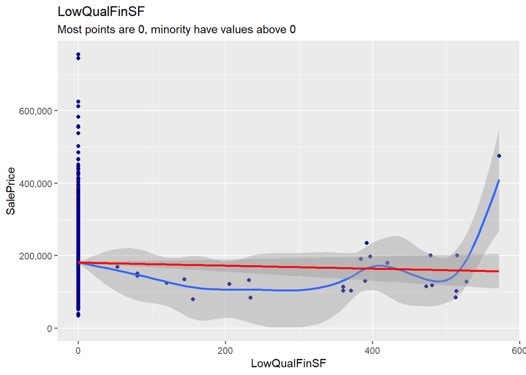

```r
ggplot(df, aes(x = LowQualFinSF, y = SalePrice)) +
  geom_point(col='dark blue') +
  scale_y_continuous(labels=comma) +
  stat_smooth(method ='auto') +
  stat_smooth(method ='lm', color = "red") +
  labs(title = "LowQualFinSF",
       subtitle = "Most points are 0, minority have values above 0")
```

This numerical variable will not be useful in regression as only 26 rows lie above 0, which is only 1.7% of the entire dataset.

Even if we exclude the zeros, we will not meet the base assumption of Central Limit Theorem (n >= 30). Hence, we’ll take note that this variable will not be useful as a predictor.

```r
df %>% select(c('LowQualFinSF', 'X1stFlrSF', 'X2ndFlrSF'))
```

```
##      LowQualFinSF X1stFlrSF X2ndFlrSF
## 1               0       856       854
## 2               0      1262         0
## 3               0       920       866
## 4               0       961       756
## 5               0      1145      1053
## 6               0       796       566
## 7               0      1694         0
## 8               0      1107       983
## 9               0      1022       752
## 10              0      1077         0
## 11              0      1040         0
## 12              0      1182      1142
## 13              0       912         0
## 14              0      1494         0
```

[output cut: 1446 more lines]

#### 3.2.3 Basement Area

We can see from below that TotalBsmtSF is simply the sum of these 3 basement areas: BsmtFinSF1, BsmtFinSF2 and BsmtUnfSF.

```r
df %>% select(c("BsmtFinSF1", "BsmtFinSF2", "BsmtUnfSF", "TotalBsmtSF")) %>% head(10)
```

```
##    BsmtFinSF1 BsmtFinSF2 BsmtUnfSF TotalBsmtSF
## 1         706          0       150         856
## 2         978          0       284        1262
## 3         486          0       434         920
## 4         216          0       540         756
## 5         655          0       490        1145
## 6         732          0        64         796
## 7        1369          0       317        1686
## 8         859         32       216        1107
## 9           0          0       952         952
## 10        851          0       140         991
```

This introduces unneccesary correlations. We can improve this by capturing the proportion of the basement that are unfinished with new variable.

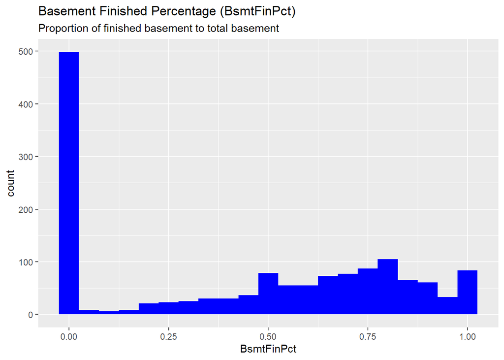

```r
df$BsmtFinPct <- (df$BsmtFinSF1 + df$BsmtFinSF2) / df$TotalBsmtSF
df$BsmtFinPct[is.na(df$BsmtFinPct)] <- 0

ggplot(df, aes(BsmtFinPct)) +
  geom_histogram(binwidth=0.05, fill='blue') +
  labs(title = "Basement Finished Percentage (BsmtFinPct)",
       subtitle = "Proportion of finished basement to total basement")
```

We see that there is approximately 500 houses with either no basement, or an unfinished basement (which is as though there’s no basement).

BsmtFinSF1 and BsmtFinSF2 are simply areas broken up by type of usage, i.e. if the basement has 2 types of usages, BsmtFinSF2 will be more than 0.

### 3.3 Bathrooms

Individually, the bathroom variables (FullBath, HalfBath, BsmtFullBath, BsmtHalfBah) do now show high correlation with Sale Price. However, our group expects that consolidating all of them into one variable will show its importance. We’ll create a new variable called Total Bathrooms.

With reference to data_descriptions, a halfbath refers to a bathroom with only a sink and a toilet. Therefore, in calculating Total Bathrooms, we’ll count half baths accordingly as 0.5 of a bathroom.

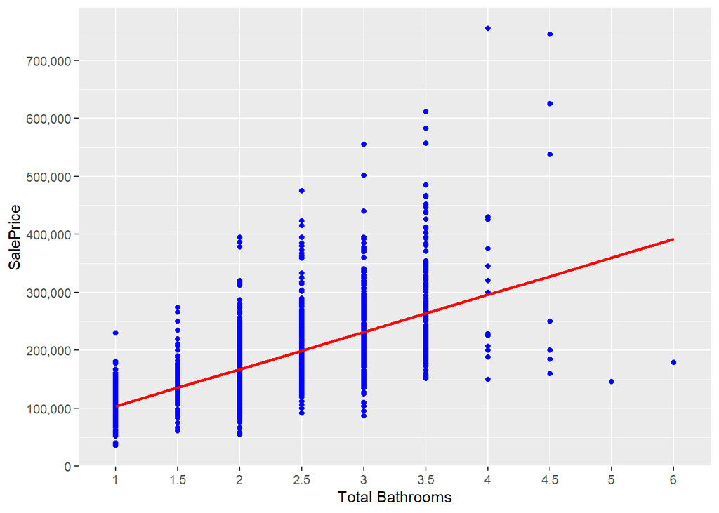

```r
df$TotalBaths = df$FullBath + 0.5*df$HalfBath + df$BsmtFullBath + 0.5*df$BsmtHalfBath

ggplot(df, aes(x=as.factor(TotalBaths), y=SalePrice)) + geom_point(col='blue') + geom_smooth(method='lm', se=FALSE, col='red', aes(group=1)) + scale_y_continuous(breaks=seq(0, 800000, 100000), labels=comma) + xlab('Total Bathrooms')
```

We can observe that number of bathrooms are now decently positively correlated with sale price.

### 3.4 RoofMatl

RoofMatl contains a lot of types which might lead to issues during our prediction modelling later on. We’ll resolve this by manually declaring the factor levels.

```r
df$RoofMatl %>% summary()
```

```
## ClyTile CompShg Membran   Metal    Roll Tar&Grv WdShake WdShngl
##       1    1434       1       1       1      11       5       6
```

```r
df$RoofMatl <- df$RoofMatl %>% as.character %>%
  factor(levels = c("ClyTile", "CompShg", "Metal", "Roll", "Tar&Grv", "WdShake", "WdShngl"))
```

### 3.5 Condition1, Condition2

From data_description, we can see that Condition1 and Condition2 are simply columns to show whether a house is located near certain areas as defined below:

Condition1: Proximity to various conditions Condition2: Proximity to various conditions (if more than one is present) Artery: Adjacent to arterial street Feedr: Adjacent to feeder street Norm: Normal RRNn: Within 200’ of North-South Railroad RRAn: Adjacent to North-South Railroad PosN: Near positive off-site feature–park, greenbelt, etc. PosA: Adjacent to postive off-site feature RRNe: Within 200’ of East-West Railroad RRAe: Adjacent to East-West Railroad

```r
df$Condition1 %>% summary()
```

```
## Artery  Feedr   Norm   PosA   PosN   RRAe   RRAn   RRNe   RRNn
##     48     81   1260      8     19     11     26      2      5
```

```r
df$Condition2 %>% summary()
```

```
## Artery  Feedr   Norm   PosA   PosN   RRAe   RRAn   RRNn
##      2      6   1445      1      2      1      1      2
```

```r
df$Condition1 <- df$Condition1 %>% as.character()
df$Condition2 <- df$Condition2 %>% as.character()

# Pure dummies
df$hasArtery <- ifelse(df$Condition1 == "Artery", 1, ifelse(df$Condition2 == "Artery", 1, 0))
df$hasFeedr <- ifelse(df$Condition1 == "Feedr", 1, ifelse(df$Condition2 == "Feedr", 1, 0))

# Grouped dummies
df$hasRRe <- ifelse(df$Condition1 %in% c("RRNe","RRAe"), 1, ifelse(df$Condition2 %in% c("RRNe","RRAe"), 1, 0))
df$hasRRn <- ifelse(df$Condition1 %in% c("RRNn","RRAn"), 1, ifelse(df$Condition2 %in% c("RRNn","RRAn"), 1, 0))
df$hasPos <- ifelse(df$Condition1 %in% c("PosN","PosA"), 1, ifelse(df$Condition2 %in% c("PosN","PosA"), 1, 0))

# Remove these conditions as they are unsuitable in all our models
dfCondition1 <- NULL
dfCondition2 <- NULL
```

## 4. Data Visualization: Numerical Variables

### 4.1 Target Variable: SalePrice

To better understand how the spread of SalePrice looks over the entire dataset, we will plot a histogram chart of it.

```r
df$SalePrice %>% is.na() %>% unique() # There are no NAs in SalePrice.
```

```
## [1] FALSE
```

```r
summary(df$SalePrice)
```

```
##    Min. 1st Qu.  Median    Mean 3rd Qu.    Max.
##   34900  129975  163000  180921  214000  755000
```

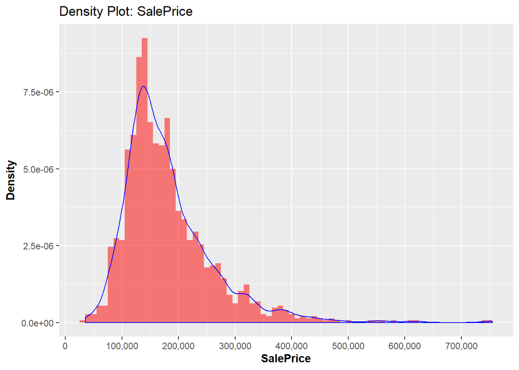

```r
ggplot(df, aes(x = SalePrice)) +
  geom_histogram(aes(y = ..density..), fill = 'red', alpha = 0.5, binwidth=10000) +
  scale_x_continuous(breaks=seq(0, 800000, 100000), labels=comma) +
  geom_density(colour = 'blue') +
  xlab(expression(bold('SalePrice'))) +
  ylab(expression(bold('Density'))) +
  labs(title = "Density Plot: SalePrice")
```

This makes sense, as not many people can afford expensive housing.

The tails of the distribution are significantly off from the peak, which indicates a significant kurtosis.

```r
cat('Skewness: ', skewness(df$SalePrice))
```

```
## Skewness:  1.880941
```

```r
cat('\nKurtosis: ', kurtosis(df$SalePrice))
```

```
##
## Kurtosis:  9.509812
```

In order to better fix the skewness and kurtosis, we shall log transform SalePrice, and create a new variable SalePriceLog to reflect this transformation.

```r
df$SalePriceLog <- log(df$SalePrice)
```

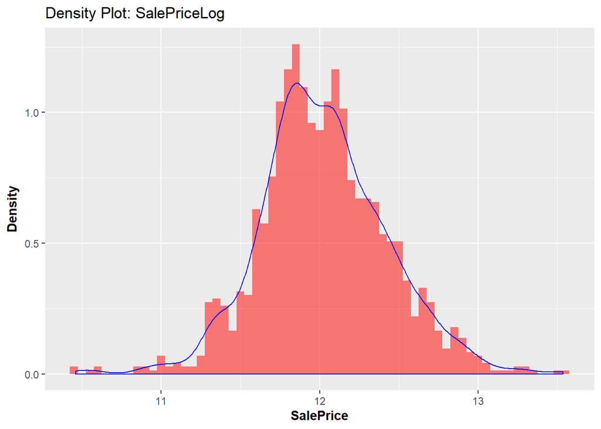

```r
ggplot(df, aes(x = SalePriceLog)) +
  geom_histogram(binwidth = 0.05, aes(y = ..density..), fill = 'red', alpha = 0.5) +
  geom_density(colour = 'blue') +
  xlab(expression(bold('SalePrice'))) +
  ylab(expression(bold('Density'))) +
  labs(title = "Density Plot: SalePriceLog")
```

```r
skewness(df$SalePriceLog)
```

```
## [1] 0.1212104
```

```r
kurtosis(df$SalePriceLog)
```

```
## [1] 3.802656
```

As can be seen above, there is much improvement in terms of both skewness and kurtosis, which will translate to more effective results when predicting.

Next, we’ll take a look at the correlation between each numeric variable and SalePrice in order to ascertain the significant predictors.

### 4.2 Correlation Analysis

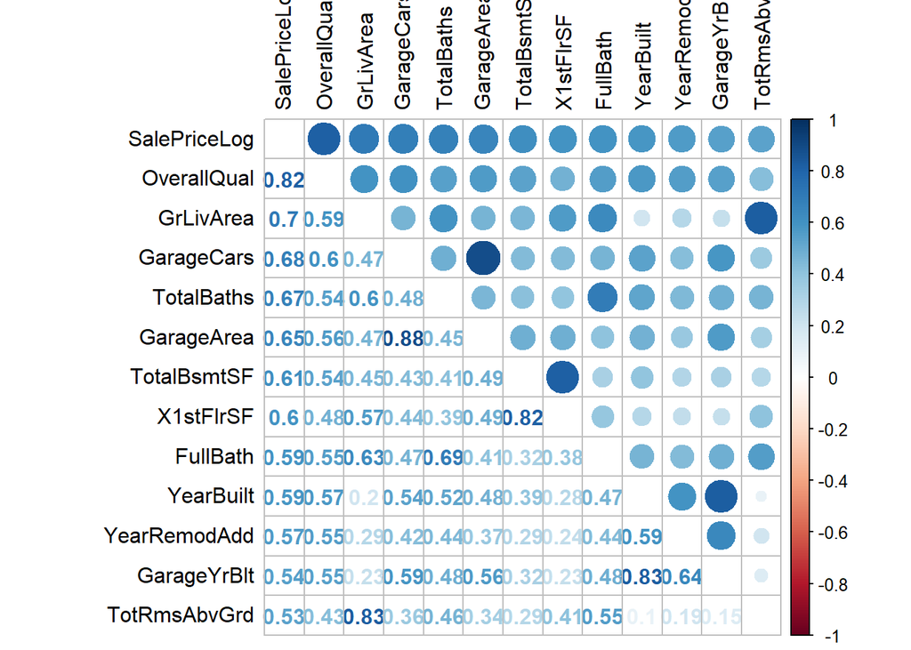

```r
# Picking out the numeric Variables and SalePrice
numVars <- df[,which(sapply(df, is.numeric))]
numVars = numVars[-34]

# Correlations of each numeric variable to SalePrice
numCors <- cor(numVars, use='pairwise.complete.obs')

# Sorting the correlations by their correlation with SalePrice
numCorsSorted <- sort(numCors[, 'SalePriceLog'], decreasing=TRUE)

# Picking out only the significant variables with correlation > 0.5
varHighCorr <- names(which(numCorsSorted>0.5, TRUE))

# Creating a new matrix with just the highly correlated variables
numCorMtx <- numCors[varHighCorr, varHighCorr]

# Plotting the correlation plot
corrplot.mixed(numCorMtx, tl.col='black', tl.pos='lt')
```

However, we can also see that some of the variables are also highly correlated with each other, indicating an issue of multicollinearity.

Of note are GarageArea (Size of Garage in sqft) and GarageCars (Size of Garage in car capacity) with a correlation of 0.88, X1stFlrSF (Size of 1st floor in sqft) and TotalBsmtSF (Size of basement in sqft) with a correlation of 0.82, and TotRmsAbvGrd (Number of rooms above ground) and GrLivArea (Area of above-ground living area in sqft) with a correlation of 0.83.

From the descriptions of the variables above alone, it makes sense that they will be highly correlated. For e.g., the size of a garage can be calculated in sqft, but it can also be calculated in terms of number of cars.

First, we’ll take a closer look at the 2 most important variables: OverallQual and GrLivArea.

### 4.3 A closer look at OverallQual

OverallQual refers to the rating of the overall material and finishing of the house. It makes sense that if the rating of the materials and finishing is high, sale price should be high as well.

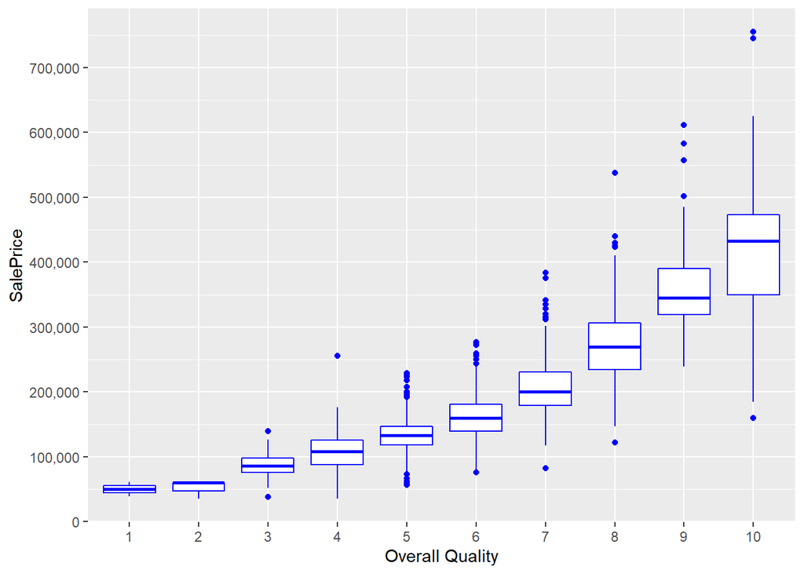

```r
ggplot(df, aes(x=factor(OverallQual), y=SalePrice)) +
  geom_boxplot(color='blue') + labs(x='Overall Quality') +
  scale_y_continuous(breaks=seq(0, 800000, 100000), labels = comma)
```

We see that there as a clear positive relationship between the overall quality of the house and its sale price. As quality increases, sale price increases. Hence, the high correlation can be visually seen from this graph.

Since OverallQual seems to be the most correlated with SalePrice, we’ll do an initial exploration into the interaction between SalePrice and OverallQual.

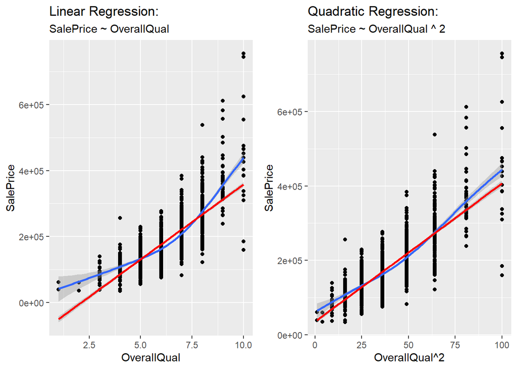

```r
p1 <- ggplot(df, aes(x = OverallQual, y=SalePrice)) +
  geom_point() +
  stat_smooth(method ='auto') +
  stat_smooth(method ='lm', color = "red") +
  labs(title = "Linear Regression:",
       subtitle = "SalePrice ~ OverallQual")

p2 <- ggplot(df, aes(x = OverallQual^2, y=SalePrice)) +
  geom_point() +
  stat_smooth(method ='auto') +
  stat_smooth(method ='lm', color = "red") +
  labs(title = "Quadratic Regression:",
       subtitle = "SalePrice ~ OverallQual ^ 2")

grid.arrange(p1,p2,nrow=1)
```

We can also observe that OverallQual exhibits a quadratic relationship to SalePrice. From the above plot, we can see the blue line (geom_smooth using method = “gam”) and the red line (geom_smooth using method = “lm”) coincides more smoothly for the quadratic regression.

### 4.4 A closer look at GrLivArea

GrLivArea refers to the area, in square feet, of the living area above ground. It also makes sense that if the house has a large above-ground living area, the house should be fairly expensive.

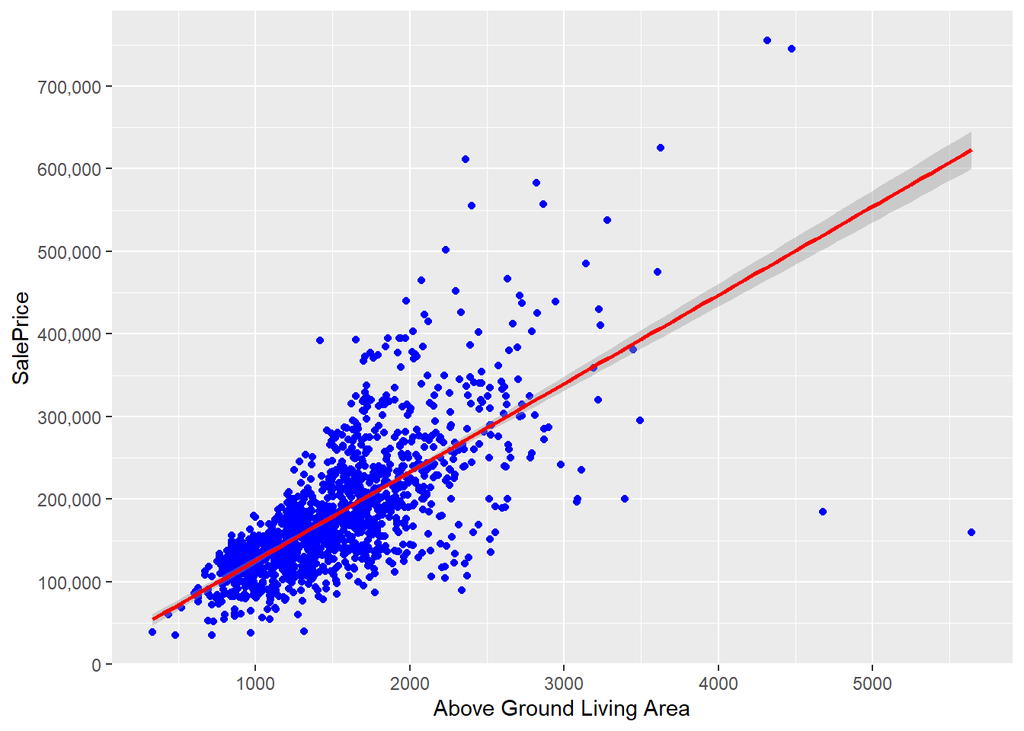

```r
ggplot(df, aes(x=GrLivArea, y=SalePrice)) +
  geom_point(color='blue') + geom_smooth(method='lm', color='red') +
  scale_y_continuous(breaks=seq(0, 800000, 100000), labels=comma) +
  labs(x='Above Ground Living Area')
```

We see that there is also a clear positive trend here between sale price and above ground living area, thereby visually proving the correlation.

However, we can see two outlier points here. Although their above ground living area is quite high (> 4500sqft), but their sale price is abnormally low ( < 250,000). Although we won’t be taking them out of the dataset yet as there could be other factors that might explain their low saleprice, we’ll take note of the two points first.

```r
which(df$GrLivArea>4500 & df$SalePrice<250000, arr.ind=TRUE)
```

```
## [1]  524 1299
```

We find that the two outliers are Row Number 524, and 1299.

### 4.5 Age and isRemodelled

Next, we’ll take a look at the interaction of Age and isRemodelled with Sale Price.

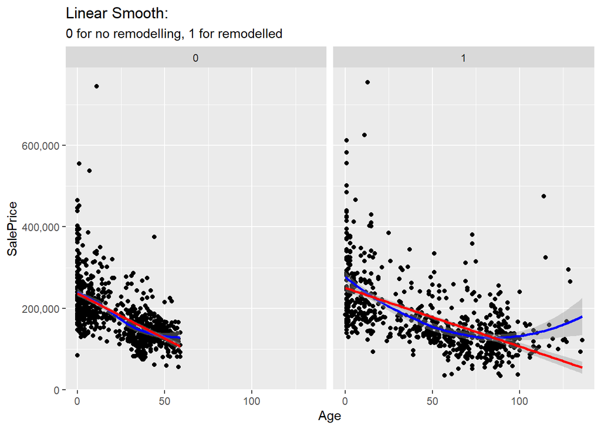

```r
ggplot(df, aes(x = Age, y = SalePrice)) +
  geom_point() +
  scale_y_continuous(labels=comma) +
  stat_smooth(method ='auto', color = 'blue') +
  stat_smooth(method ='lm', color = "red") +
  facet_wrap(~isRemodelled) +
  labs(title = "Linear Smooth:",
       subtitle = "0 for no remodelling, 1 for remodelled")
```

We find that no matter whether a house has been remodelled before or not, there is a general downward trend with Age. As the house gets older, its sale price decreases.

As the Age increases past 90, the sale price looks like it’s hitting a limit. This makes sense as no matter how old the house is, it shouldn’t be selling for dirt cheap (less than 100,000) as the owner won’t be profiting off of it then.

Overall, we can conclude that sale price decreases with age, and hits a limit past 90.

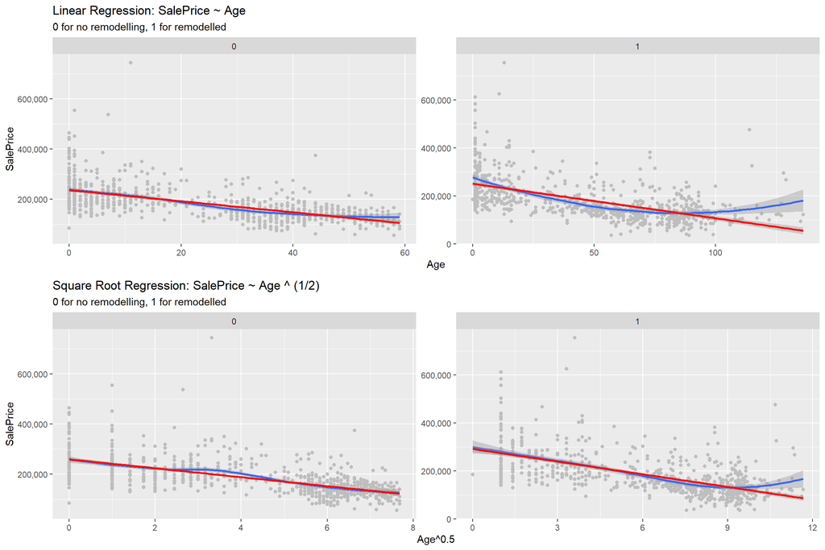

```r
p1 <- ggplot(df, aes(x = Age, y = SalePrice)) +
  geom_point(col='grey') +
  scale_y_continuous(labels=comma) +
  stat_smooth(method ='auto') +
  stat_smooth(method ='lm', color = "red") +
  facet_wrap(~isRemodelled, scales = "free") +
  labs(title = "Linear Regression: SalePrice ~ Age",
       subtitle = "0 for no remodelling, 1 for remodelled")

p2 <- ggplot(df, aes(x = Age ^ 0.5, y = SalePrice)) +
  geom_point(col='grey') +
  scale_y_continuous(labels=comma) +
  stat_smooth(method ='auto') +
  stat_smooth(method ='lm', color = "red") +
  facet_wrap(~isRemodelled, scales = "free") +
  labs(title = "Square Root Regression: SalePrice ~ Age ^ (1/2)",
       subtitle = "0 for no remodelling, 1 for remodelled")

grid.arrange(p1,p2,nrow=2)
```

We discovered that there is a square root relationship between Age and SalePrice as seen in the above plots. Transforming age by square-rooting it improves the linear smoothing.

```
## Correlation(SalePrice, Age):  -0.5233504
```

```
##
## Correlation(SalePrice, Age ^ 0.5):  -0.570671
```

Comparing on correlation, we can see that square-rooting Age increases its correlation with SalePrice by about 5%.

### 4.6 Porches

We noticed that there are many variables regarding porches, and we wonder why are there so many variables about them. Let’s take a look at all of them.

WoodDeckSF: Wood deck area in square feet OpenPorchSF: Open porch area in square feet EnclosedPorch: Enclosed porch area in square feet X3SsnPorch: Three season porch area in square feet ScreenPorch: Screen porch area in square feet

Based on surface research, Wood deck is a porch without any roofing, and the other types of porches are just different porch types. A house can have various different porches that are of different types. We will aggregate them by summing their area into a new variable TotalPorchSF to analyse it later.

```r
df$TotalPorchSF <- df$WoodDeckSF + df$OpenPorchSF + df$EnclosedPorch + df$X3SsnPorch + df$ScreenPorch
cor(df$TotalPorchSF, df$SalePriceLog)
```

```
## [1] 0.3983867
```

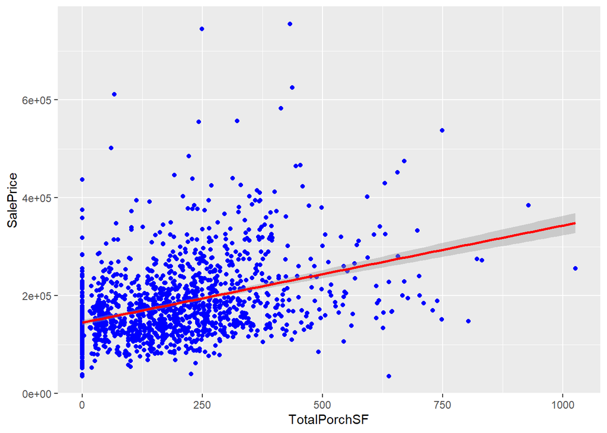

```r
ggplot(df, aes(x=TotalPorchSF, y=SalePrice)) + geom_point(col='blue') + geom_smooth(method='lm', col='red', aes(group=1))
```

## 5. Data Visualization: Categorical Variables

### 5.1 Neighborhood

We’re interested to find out how Neighbourhood affects sale prices. We expect it to differ highly between neighbourhoods - high-end neighbourhoods should have more expensive houses, and vice versa.

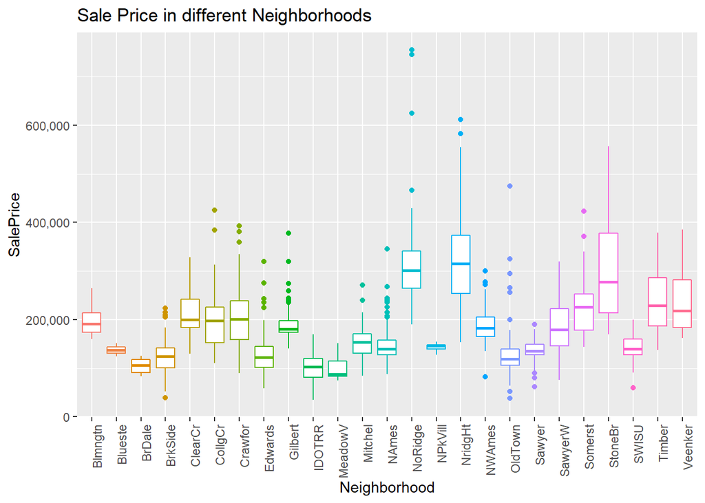

```r
ggplot(df, aes(x = Neighborhood, y = SalePrice)) +
  geom_boxplot(aes(color = Neighborhood)) +
  scale_y_continuous(labels=comma) +
  labs(title = "Sale Price in different Neighborhoods") +
  theme(axis.text.x = element_text(angle = 90, hjust = 1),
        legend.position = 'None')
```

As expected, we see that there is a wide variation of Sale Prices amongst the neighbourhoods. Some neighbourhoods have a wider spread, some have a very tight spread. Examples are NoRidge, which has a few points that are sold at prices more than 600,000, and NPkVIII, which has a very tight spread, indicating houses in that neighbourhood are consistently sold around that price.

We can conclude that Neighbourhood will be a potential important predictor variable for our prediction models.

However, due to the significantly high number of different neighbourhoods (25 neighbourhoods), our group feels it introduces an unnecessary complexity to the data which will affect our prediction modelling. We’ll look into visualizing the median and mean saleprices across all the neighbourhoods and then attempt to bin them more generally.

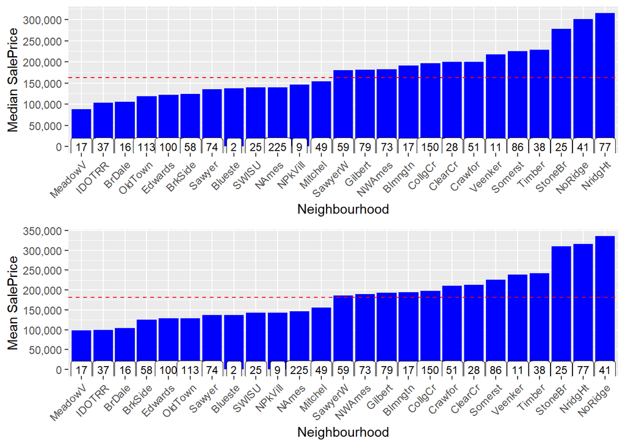

```r
# Visualization for median sale price
medianbin <- ggplot(df, aes(x=reorder(Neighborhood, SalePrice, FUN=median), y=SalePrice)) +
  geom_bar(stat='summary', fun.y = "median", fill='blue') + labs(x='Neighbourhood', y='Median SalePrice') +
  theme(axis.text.x = element_text(angle = 45, hjust = 1)) +
  scale_y_continuous(breaks= seq(0, 800000, by=50000), labels = comma) +
  geom_label(stat = "count", aes(label = ..count.., y = ..count..), size=3) +
  geom_hline(yintercept=median(df$SalePrice), linetype="dashed", color = "red")

# Visualization for mean sale price
meanbin <- ggplot(df, aes(x=reorder(Neighborhood, SalePrice, FUN=mean), y=SalePrice)) +
  geom_bar(stat='summary', fun.y = "mean", fill='blue') + labs(x='Neighbourhood', y="Mean SalePrice") +
  theme(axis.text.x = element_text(angle = 45, hjust = 1)) +
  scale_y_continuous(breaks= seq(0, 800000, by=50000), labels = comma) +
  geom_label(stat = "count", aes(label = ..count.., y = ..count..), size=3) +
  geom_hline(yintercept=mean(df$SalePrice), linetype="dashed", color = "red")

grid.arrange(medianbin, meanbin)
```

We can observe that both plots on the mean and median sale prices agree on the extreme 3 neighbourhoods on both sides of the spectrum. From this, we can bin the neighbourhoods into 3 more general categories:

Poor: MeadowV, IDOTRR, BrDale (0) Rich: StoneBr, NoRidge, NridgHt (2) Average: Everything else (1)

```r
df$NghbrhdCat[df$Neighborhood %in% c('StoneBr', 'NoRidge', 'NridgHt')]  <-  2
df$NghbrhdCat[df$Neighborhood %in% c('MeadowV', 'IDOTRR', 'BrDale')] <- 0
df$NghbrhdCat[!df$Neighborhood %in% c('MeadowV', 'IDOTRR', 'BrDale', 'StoneBr', 'NoRidge', 'NridgHt')] <- 1
df$NghbrhdCat <- as.factor(df$NghbrhdCat)
table(df$NghbrhdCat)
```

```
##
##    0    1    2
##   70 1247  143
```

### 5.2 MSSubClass

Next, we’ll take a look at MSSubClass. From data_descriptions, MSSubClass describes the type of dwelling involved in the sale, with 16 different factors indicating a different type of house.

We expect sale price to vary between different MSSubClasses too. Houses with a MSSubClass indicating a high-end house (e.g. 2-1/2 Storey) are definitely worth more than a small house (e.g. 1-storey).

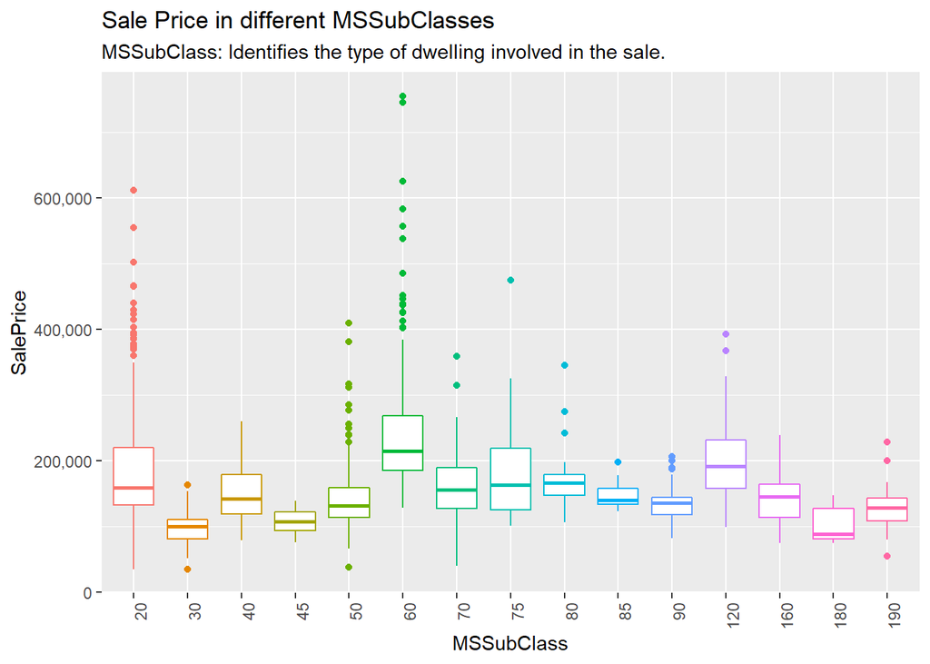

```r
ggplot(df, aes(x = MSSubClass, y = SalePrice)) +
  geom_boxplot(aes(color = MSSubClass)) +
  scale_y_continuous(labels=comma) +
  labs(title = "Sale Price in different MSSubClasses",
        subtitle = "MSSubClass: Identifies the type of dwelling involved in the sale.") +
  theme(axis.text.x = element_text(angle = 90, hjust = 1),
        legend.position = 'None')
```

As expected, sale prices do differ between MSSubClasses, and by a lot as well. Again, we see that some classes have a wide spread (20, 60), and some has a tight spread (45).

We can conclude that MSSubClass will be a potential important predictor variable in our prediction models later on.

Across the MSSubClasses, as GrLivArea increases, SalePrice increases as well.

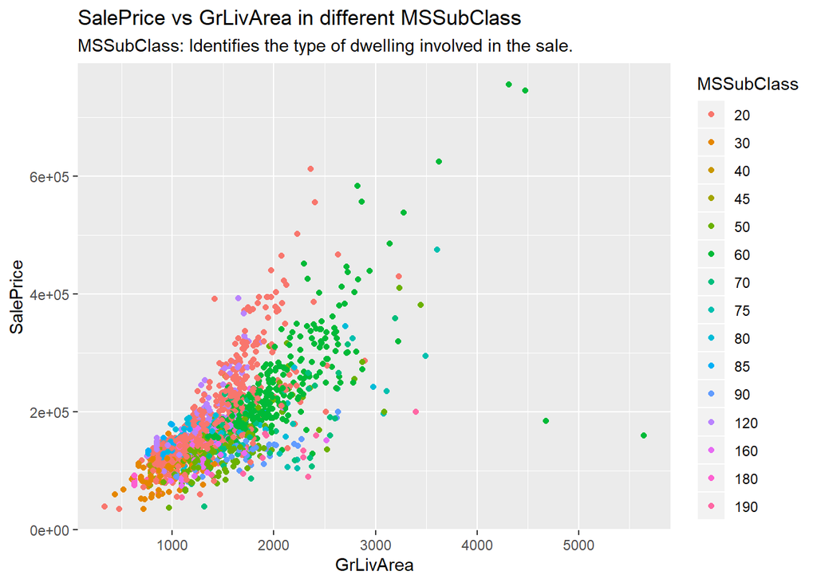

```r
ggplot(df, aes(x = GrLivArea, y = SalePrice, color = MSSubClass)) +
  geom_point() +
  labs(title = "SalePrice vs GrLivArea in different MSSubClass",
       subtitle = "MSSubClass: Identifies the type of dwelling involved in the sale.")
```

This is further evidence that GrLivArea is a very important variable with regards to Sale Price, which makes sense as the larger a house, it should potentially be worth more.

We’ll create a new variable that adds up both the total area above ground and total area below ground to reflect Total Area of a House better.

### 5.3 PoolQC

There’s only 7 data points that have a pool, but PoolQC has a high correlation with sale price. We’ll create a hasPool variable to better reflect this information.

```r
df$hasPool <- ifelse(df$PoolQC == 'None', 0, 1)
table(df$hasPool)
```

```
##
##    0    1
## 1453    7
```

### 5.4 GarageType, GarageFinish, GarageQual, GarageCond

We noticed that there are many variables surrounding Garage. We’ll visualize and analyse them to see if any of them are describing the same things.

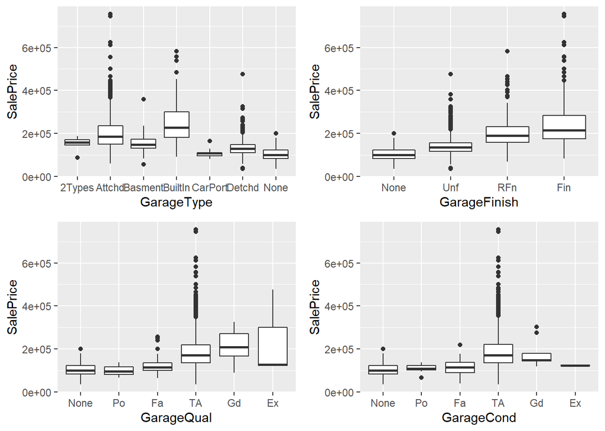

```r
a <- ggplot(df, aes(x=GarageType, y=SalePrice)) + geom_boxplot()
b <- ggplot(df, aes(x=GarageFinish, y=SalePrice)) + geom_boxplot()
c <- ggplot(df, aes(x=GarageQual, y=SalePrice)) + geom_boxplot()
d <- ggplot(df, aes(x=GarageCond, y=SalePrice)) + geom_boxplot()

grid.arrange(a, b, c, d)
```

```r
chisq.test(table(df$GarageQual, df$GarageCond))
```

```
##
##  Pearson's Chi-squared test
##
## data:  table(df$GarageQual, df$GarageCond)
## X-squared = 3633.1, df = 25, p-value < 2.2e-16
```

Using a Chi-squared test of independence on both of them, we observe a significant p-value, which indicates a high correlation with each other.

We’ll take note of this instance of collinearity for our multi-regression model later on.

### 5.5 TotalArea

In this section, we create a new variable TotalArea to better reflect the total area (in square feet) of the house. We do this by summing up the above-ground living area, and the basement area.

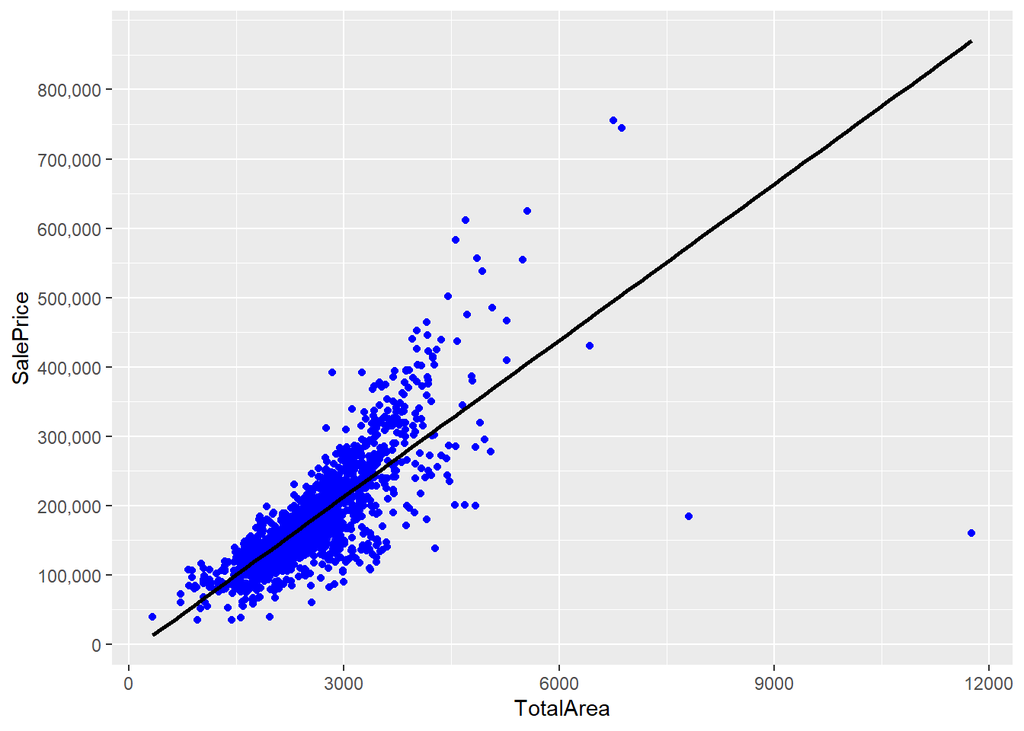

```r
df$TotalArea <- df$GrLivArea + df$TotalBsmtSF

ggplot(df, aes(x=TotalArea, y=SalePrice)) +
  geom_point(col='blue') +
  geom_smooth(method = "lm", se=FALSE, color="black", aes(group=1)) +
  scale_y_continuous(breaks= seq(0, 800000, by=100000), labels = comma)
```

```r
cor(df$GrLivArea, df$SalePrice)
```

```
## [1] 0.7086245
```

```r
cor(df$TotalArea, df$SalePrice)
```

```
## [1] 0.7789588
```

The correlation with Sale Price is even larger now. With the increased correlation, it also means the outliers are now more important. Let’s see if they’re the same outliers as we identified in our exploration with GrLivArea earlier.

```r
df[df$TotalArea > 7500, ]
```

```
##      MSSubClass MSZoning LotFrontage LotArea Street Alley LotShape
## 524          60       RL         130   40094   Pave  None      IR1
## 1299         60       RL         313   63887   Pave  None      IR3
##      LandContour LotConfig LandSlope Neighborhood Condition1 Condition2
## 524          Bnk    Inside       Gtl      Edwards       PosN       PosN
## 1299         Bnk    Corner       Gtl      Edwards      Feedr       Norm
##      BldgType HouseStyle OverallQual OverallCond YearBuilt YearRemodAdd
## 524      1Fam     2Story          10           5      2007         2008
## 1299     1Fam     2Story          10           5      2008         2008
##      RoofStyle RoofMatl Exterior1st Exterior2nd MasVnrType MasVnrArea
## 524        Hip  CompShg     CemntBd     CmentBd      Stone        762
## 1299       Hip  ClyTile      Stucco      Stucco      Stone        796
##      ExterQual ExterCond Foundation BsmtQual BsmtCond BsmtExposure
## 524         Ex        TA      PConc       Ex       TA           Gd
## 1299        Ex        TA      PConc       Ex       TA           Gd
##      BsmtFinType1 BsmtFinSF1 BsmtFinType2 BsmtFinSF2 BsmtUnfSF TotalBsmtSF
## 524           GLQ       2260          Unf          0       878        3138
## 1299          GLQ       5644          Unf          0       466        6110
##      Heating HeatingQC CentralAir Electrical X1stFlrSF X2ndFlrSF
## 524     GasA        Ex          Y      SBrkr      3138      1538
## 1299    GasA        Ex          Y      SBrkr      4692       950
##      LowQualFinSF GrLivArea BsmtFullBath BsmtHalfBath FullBath HalfBath
## 524             0      4676            1            0        3        1
## 1299            0      5642            2            0        2        1
##      BedroomAbvGr KitchenAbvGr KitchenQual TotRmsAbvGrd Functional
## 524             3            1          Ex           11        Typ
## 1299            3            1          Ex           12        Typ
##      Fireplaces FireplaceQu GarageType GarageYrBlt GarageFinish GarageCars
## 524           1          Gd    BuiltIn        2007          Fin          3
## 1299          3          Gd     Attchd        2008          Fin          2
##      GarageArea GarageQual GarageCond PavedDrive WoodDeckSF OpenPorchSF
## 524         884         TA         TA          Y        208         406
## 1299       1418         TA         TA          Y        214         292
##      EnclosedPorch X3SsnPorch ScreenPorch PoolArea PoolQC Fence
## 524              0          0           0        0   None  None
## 1299             0          0           0      480     Gd  None
##      MiscFeature MiscVal MoSold YrSold SaleType SaleCondition SalePrice
## 524         None       0     10   2007      New       Partial    184750
## 1299        None       0      1   2008      New       Partial    160000
##      Age isRemodelled has2ndFlr BsmtFinPct TotalBaths hasArtery hasFeedr
## 524    0            1         1  0.7202040        4.5         0        0
## 1299   0            0         1  0.9237316        4.5         0        1
##      hasRRe hasRRn hasPos SalePriceLog TotalPorchSF NghbrhdCat hasPool
## 524       0      0      1     12.12676          614          1       0
## 1299      0      0      0     11.98293          506          1       1
##      TotalArea
## 524       7814
## 1299     11752
```

The outliers are the same! Let’s attempt to remove them and see how it affects the correlation.

```r
cor(df$SalePrice[-c(524, 1299)], df$TotalArea[-c(524, 1299)])
```

```
## [1] 0.829042
```

Removing the outliers actually increased the correlation by 5% to 82.9%. This is further evidence that these 2 outliers are true outliers. Although removing outliers may have an impact on a huge data set such as this, we’ll keep things simple and remove them later on for more accurate results when conducting our prediction modelling.

Now that we’ve extensively looked at the predictor variables, we’ll now move on to pre-processing for our Prediction Modelling.

## 6. Additional Data Preperation

Prior to our prediction modelling, we’ll need to preprocess our variables as per our exploratory and visualization phases. There are many variables that we would need to account for.

### 6.2 Assigning new variables with observed explored relationship

From our exploratory analysis, we discovered that OverallQual has a quadratic relationship with SalePrice, and Age has a square-root relationship with SalePrice. We’ll add those variables accordingly.

```r
df$OverallQual2 <- df$OverallQual ^ 2
df$Age2 <- df$Age ^ 0.5
```

### 6.3 Pre-processing variables from exploratory phase for multi-regression

We introduced many variables in the previous sections. Let’s go through them one by one. We’ll be dropping similar variables in order to account for multi-collinearity, but only for multi-regression modelling. We’ll keep all the variables for our other models.

1. Age and isRemodelled

We introduced Age by calculating the difference between YrSold and YearBuilt, as it is more informative than simply telling us when the house is sold and built.

We introduced isRemodelled which is a 1 if a house has been remodelled before (YrBuilt != YearRemodAdd), and 0 if a house has not been remodelled before (YrBuilt == YearRemodAdd).

**We can drop YrSold, YearBuilt, and YearRemodAdd.**

2. LowQualFinSF

**We can drop LowQualFinSf.**

3. GrLivArea, X1stFlrSF, X2ndFlrSf.

We determined that GrLivArea ia a sum of X1stFlrSF and X2ndFlrSF. We introduced a new variable has2ndFlr to take into account whether a house has a second storey or not.

**We can drop X1stFlrSF and X2ndFlrSF.**

4. TotalBsmtSF, BsmtFinSF1, BsmtFinSF2, BsmtUnfSF

We determined that TotalBsmtSF = BsmtFinSF1 + BsmtFinSF2 + BsmtUnfSF.

We introduced a new variable BsmtFinPct which is a percentage of basement that is finished.

**We can drop BsmtFinSF1, BsmtFinSF2, BsmtUnfSF.**

5. Bathrooms

We introduced a new variable TotalBaths which takes into account all the bathrooms in the house.

**We can drop FullBath, HalfBath, BsmtFullBath, BsmtHalfBath.**

6. Neighbourhoods

We binned neighbourhoods into NghbrhdCat in attempt to reduce the degrees of freedom in Multi-regression

**We can drop Neighborhood.**

Referring to the correlation matrix in 4.2, there are instances of multicollinearity that we need to account for.

7. TotRmsAbvGrd and GrLivArea

GrLivArea is very similar to TotRmsAbvGrd and are highly correlated.

GrLivArea = area above ground in square feet TotRmsAbvGrd = rooms above ground

**We’ll drop TotRmsAbvGrd as GrLivArea is more correlated.**

8. GarageCars and GarageArea

Similar to 7, GarageCars and GarageArea describe the size of the garage in different terms.

**We’ll drop GarageArea as GarageCars is more correlated.**

9. TotalArea, TotalBsmtSF, GrLivArea

We created a new variable TotalArea to take the total living area space, which is more predictive of sale price than the individual broken down areas.

**We can drop TotalBsmtSF, GrLivArea.**

10. PoolQC

**We will drop PoolQC as we will be using hasPool.**

### 6.4 Ordering numeric variables by correlation

Now that we’ve accounted for the variables that we explored in our exploratory phase, let’s look at the rest of the numeric variables ordered by correlation.

```r
numVars <- df[,which(sapply(df, is.numeric))]
numCors <- cor(numVars, use='pairwise.complete.obs')
numCorsSorted <- sort(numCors[, 'SalePriceLog'], decreasing=TRUE)
numCorsSorted
```

```
##  SalePriceLog     SalePrice   OverallQual  OverallQual2     TotalArea
##   1.000000000   0.948373731   0.817184418   0.812373682   0.773276841
##     GrLivArea    GarageCars    TotalBaths    GarageArea   TotalBsmtSF
##   0.700926653   0.680624807   0.673010594   0.650887556   0.612133975
##     X1stFlrSF      FullBath     YearBuilt  YearRemodAdd   GarageYrBlt
##   0.596981045   0.594770542   0.586570240   0.565607833   0.541072863
##  TotRmsAbvGrd    Fireplaces    MasVnrArea  TotalPorchSF    BsmtFinSF1
##   0.534422204   0.489449428   0.426775132   0.398386707   0.372023074
##   LotFrontage    WoodDeckSF   OpenPorchSF     X2ndFlrSF      HalfBath
##   0.355878470   0.334135074   0.321052972   0.319299984   0.313982250
##       LotArea  BsmtFullBath     BsmtUnfSF  BedroomAbvGr    BsmtFinPct
##   0.257319892   0.236224109   0.221985054   0.209043682   0.151214324
##     has2ndFlr   ScreenPorch        hasPos       hasPool      PoolArea
##   0.150549402   0.121207605   0.087463448   0.069834987   0.069797806
##    X3SsnPorch        hasRRn    BsmtFinSF2  BsmtHalfBath       MiscVal
##   0.054900226   0.007884389   0.004832411  -0.005149094  -0.020020820
##        hasRRe   OverallCond  LowQualFinSF  isRemodelled     hasArtery
##  -0.032026007  -0.036867988  -0.037962803  -0.073761417  -0.130346658
##      hasFeedr  KitchenAbvGr EnclosedPorch           Age          Age2
##  -0.131934768  -0.147548088  -0.149050281  -0.587290047  -0.620941461
```

MiscVal looks very uncorrelated. We need to take a closer look at it and its corresponding categorical variable MiscFeature.

#### 6.4.1 MiscVal and MiscFeature

There are very few houses with miscellaneous features, 54 of them, which is 3.7% of the dataset.

MiscFeature also has a high correlation with saleprice - p = 0.006, so we reject the null hypothesis that sale price doesn’t differ between different misc features.

The ggplot also shows there’s a clear difference in sale price.

We conclude that we shouldn’t remove MiscVal and MiscFeature.

```r
table(df$MiscFeature)
```

```
##
## Gar2 None Othr Shed TenC
##    2 1406    2   49    1
```

```r
summary(aov(SalePriceLog ~ MiscFeature, df))
```

```
##               Df Sum Sq Mean Sq F value  Pr(>F)
## MiscFeature    4   2.29  0.5737   3.621 0.00606 **
## Residuals   1455 230.51  0.1584
## ---
## Signif. codes:  0 '***' 0.001 '**' 0.01 '*' 0.05 '.' 0.1 ' ' 1
```

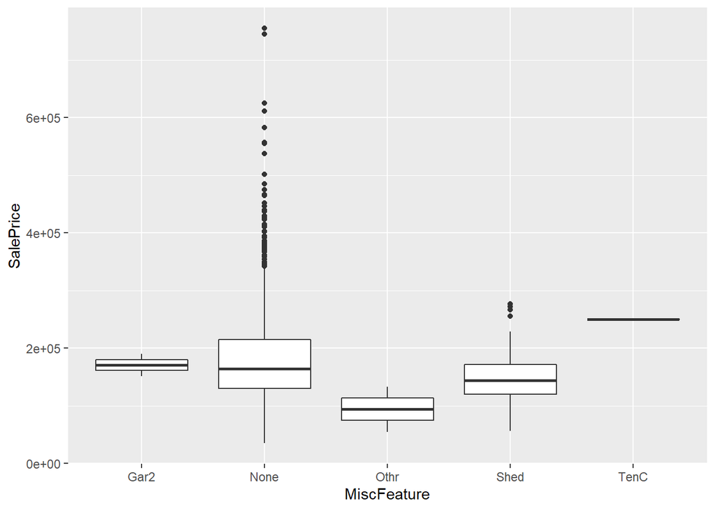

```r
ggplot(df, aes(x=MiscFeature, y=SalePrice)) + geom_boxplot()
```

### 6.5 Replacing numeric NA’s with 0’s

We’ll also replace the NA’s with 0, as our regression models are not able to take care of the NA’s.

```r
# Replace all NAs in numerical variables with 0
for (column in df %>% select_if(is.numeric) %>% names()) {
    df[,column] <- df[,column] %>% replace_na(0)
}
```

We created a new dataframe (df.mr) for use in multi-regression which accounts for the variable removing in 6.3.

```r
toRemove <- c('YrSold', 'YearBuilt', 'YearRemodAdd', 'LowQualFinSF', 'X1stFlrSF', 'X2ndFlrSF', 'BsmtFinSF1', 'BsmtFinSF2', 'BsmtUnfSF', 'TotalBsmtSF', 'FullBath', 'HalfBath', 'BsmtFullBath', 'BsmtHalfBath', 'Neighborhood', 'GrLivArea', 'GarageArea', 'TotRmsAbvGrd','OpenPorchSF', 'WoodDeckSF', 'ScreenPorch', 'X3SsnPorch', 'EnclosedPorch')
df.mr <- df[, !(names(df) %in% toRemove)]
```

We can now move on to our prediction modelling.

## 7. Prediction Models

### 7.1 Train/Test Split

We’ll split our dataset into train and test, with a 70/30 ratio.

```r
set.seed(123) # Random seed

trainSample <- sample(nrow(df), nrow(df) * 0.7) # 70% train 30% test

traindf <- df[trainSample,]
testdf <- df[-trainSample,]
```

### 7.2 Figuring out the importance of each variable with a simple exploratory RandomForest

```r
df %>% names()
```

```
##  [1] "MSSubClass"    "MSZoning"      "LotFrontage"   "LotArea"
##  [5] "Street"        "Alley"         "LotShape"      "LandContour"
##  [9] "LotConfig"     "LandSlope"     "Neighborhood"  "Condition1"
## [13] "Condition2"    "BldgType"      "HouseStyle"    "OverallQual"
## [17] "OverallCond"   "YearBuilt"     "YearRemodAdd"  "RoofStyle"
## [21] "RoofMatl"      "Exterior1st"   "Exterior2nd"   "MasVnrType"
## [25] "MasVnrArea"    "ExterQual"     "ExterCond"     "Foundation"
## [29] "BsmtQual"      "BsmtCond"      "BsmtExposure"  "BsmtFinType1"
## [33] "BsmtFinSF1"    "BsmtFinType2"  "BsmtFinSF2"    "BsmtUnfSF"
## [37] "TotalBsmtSF"   "Heating"       "HeatingQC"     "CentralAir"
## [41] "Electrical"    "X1stFlrSF"     "X2ndFlrSF"     "LowQualFinSF"
## [45] "GrLivArea"     "BsmtFullBath"  "BsmtHalfBath"  "FullBath"
## [49] "HalfBath"      "BedroomAbvGr"  "KitchenAbvGr"  "KitchenQual"
## [53] "TotRmsAbvGrd"  "Functional"    "Fireplaces"    "FireplaceQu"
## [57] "GarageType"    "GarageYrBlt"   "GarageFinish"  "GarageCars"
## [61] "GarageArea"    "GarageQual"    "GarageCond"    "PavedDrive"
## [65] "WoodDeckSF"    "OpenPorchSF"   "EnclosedPorch" "X3SsnPorch"
## [69] "ScreenPorch"   "PoolArea"      "PoolQC"        "Fence"
## [73] "MiscFeature"   "MiscVal"       "MoSold"        "YrSold"
## [77] "SaleType"      "SaleCondition" "SalePrice"     "Age"
## [81] "isRemodelled"  "has2ndFlr"     "BsmtFinPct"    "TotalBaths"
## [85] "hasArtery"     "hasFeedr"      "hasRRe"        "hasRRn"
## [89] "hasPos"        "SalePriceLog"  "TotalPorchSF"  "NghbrhdCat"
## [93] "hasPool"       "TotalArea"     "OverallQual2"  "Age2"
```

```r
set.seed(123)
rf.fit <- randomForest(SalePriceLog ~ MSSubClass + MSZoning + LotFrontage + LotArea + Street + Alley + LotShape +
                         LandContour + LotConfig + LandSlope + Neighborhood + BldgType +
                         HouseStyle + OverallQual + OverallCond + YearBuilt + YearRemodAdd + RoofStyle + RoofMatl +
                         Exterior1st + MasVnrType + MasVnrArea + ExterQual + ExterCond + Foundation +
                         BsmtQual + BsmtCond + BsmtExposure + BsmtFinType1 + BsmtFinSF1 + BsmtFinType2 + BsmtFinSF2 +
                         BsmtUnfSF + TotalBsmtSF + Heating + HeatingQC + CentralAir + Electrical + X1stFlrSF +
                         X2ndFlrSF + LowQualFinSF + KitchenQual + TotRmsAbvGrd + Functional + Fireplaces + FireplaceQu +
                         GarageType + GarageYrBlt + GarageFinish + GarageCars + GarageArea + GarageQual + GarageCond +
                         PavedDrive + WoodDeckSF + OpenPorchSF + EnclosedPorch + X3SsnPorch + ScreenPorch + PoolArea +
                         Fence + MiscFeature + MiscVal + MoSold + YrSold + SaleType +
                         SaleCondition + isRemodelled + has2ndFlr + BsmtFinPct + TotalBaths +
                         hasArtery + hasFeedr + hasRRe + hasRRn + hasPos + TotalPorchSF +
                         hasPool + TotalArea + OverallQual2 + Age2,
                       data = traindf, ntree = 500, mtry = 10, importance = TRUE)
impt <- importance(rf.fit)
impt <- impt[order(-impt[,1]),]
impt
```

```
##                  %IncMSE IncNodePurity
## TotalArea     25.3256418  17.978129297
## Neighborhood  20.9314434  12.477756815
## X1stFlrSF     16.3784016   4.693113523
## MSSubClass    16.1815506   3.136198017
## OverallQual2  15.5639223  15.693202459
## TotalBsmtSF   15.2791161   5.550401375
## OverallQual   15.1727723  13.834046265
## X2ndFlrSF     14.9576149   2.208326193
## LotArea       14.9107146   2.172869512
## GarageArea    14.2067057   4.259152378
## FireplaceQu   13.9351896   3.473839795
## TotalBaths    13.7983981   4.594671597
## TotalPorchSF  12.3466628   1.235447939
## TotRmsAbvGrd  12.0327544   1.823789461
## BsmtFinSF1    11.3508251   1.698280859
## Age2          10.6808866   4.559473247
## KitchenQual   10.6517264   5.631825430
## GarageCars    10.5196263   3.985484996
## HouseStyle    10.3365183   0.533537789
## Fireplaces    10.3265403   2.240275797
## YearRemodAdd  10.2967107   1.925153532
## YearBuilt     10.2676655   5.434235324
## OverallCond   10.0723058   0.885732675
## ExterQual     10.0178253   7.862038536
## BsmtFinPct     9.8940112   0.744953284
## GarageYrBlt    9.1618994   3.332525980
## GarageFinish   8.4164198   3.134930002
## GarageType     8.3345196   2.029721209
## BsmtFinType1   8.2010262   0.624731253
## BsmtUnfSF      8.1831924   0.812807630
## MSZoning       8.0591544   0.494370150
## Exterior1st    7.8293564   1.234186781
## BsmtQual       7.7695695   3.440644566
## OpenPorchSF    7.4142007   0.667927261
## has2ndFlr      7.3795660   0.181583767
## MasVnrArea     7.0986186   0.870227622
## CentralAir     5.9819198   0.644195051
## WoodDeckSF     5.9518758   0.488045130
## BldgType       5.8800468   0.218243529
```

[output cut: 27 more lines]

```
## YrSold         0.5667572   0.485559448
## Functional     0.4444467   0.227043767
## Street         0.3574046   0.037403725
## EnclosedPorch  0.3106425   0.226832635
## Heating        0.2462675   0.078919087
## hasRRe        -0.2164616   0.007581682
## MiscFeature   -0.8200394   0.041342968
## BsmtFinSF2    -1.1579276   0.085541055
## Electrical    -1.2153291   0.159808468
## PoolArea      -1.2580513   0.066804125
## MiscVal       -1.2908565   0.052024412
## RoofMatl      -1.5328857   0.112200320
## hasArtery     -1.5346547   0.029136804
## SaleType      -2.1364466   0.149806354
## hasPool       -2.3646780   0.040454492
```

TotalArea + LotArea + OverallQual2 + GarageCars + TotalBaths + Age2 + FireplaceQu + KitchenQual + OverallCond + HouseStyle + GarageYrBlt + ExterQual + GarageType + Fireplaces + BsmtFinPct + BedroomAbvGr + BldgType + BsmtQual + TotalPorchSF + MSZoning + Exterior1st + BsmtFinType1 + MasVnrArea + GarageFinish + NghbrhdCat + Exterior2nd + HeatingQC + Foundation + OpenPorchSF + LotShape + MasVnrType + WoodDeckSF + LotFrontage + has2ndFlr + GarageCond + CentralAir + BsmtExposure + GarageQual + KitchenAbvGr + RoofStyle + SaleCondition + LandContour + Alley + hasArtery + LandSlope + ScreenPorch + Functional + BsmtCond + PavedDrive + isRemodelled + hasFeedr + Fence + LotConfig + SaleType + MoSold + hasPos + BsmtFinType2 + MiscVal + Street + EnclosedPorch + X3SsnPorch + ExterCond + Electrical + hasRRe + MiscFeature + Heating + PoolArea + PoolQC + hasRRn + hasPool

### 7.4 Dataframe of results

we initialise a dataframe to store the accuracy and error results of our prediction modelling.

```r
results <- data.frame("Method" = character(),
                      "Train_R2" = numeric(),
                       "Test_R2" = numeric(),
                       "Train_RMSLE" = numeric(),
                       "Test_RMSLE" = numeric(),
                       stringsAsFactors=FALSE)
```

### 7.5 Multi-regression

The first model that we’ll be looking at will be multi-regression, which is a linear regression with multiple variables.

We ran the multi-regression model iteratively, removing insignificant variables one by one until all variables are significant.

```r
df %>% select_if(is.numeric) %>% names()
```

```
##  [1] "LotFrontage"   "LotArea"       "OverallQual"   "OverallCond"
##  [5] "YearBuilt"     "YearRemodAdd"  "MasVnrArea"    "BsmtFinSF1"
##  [9] "BsmtFinSF2"    "BsmtUnfSF"     "TotalBsmtSF"   "X1stFlrSF"
## [13] "X2ndFlrSF"     "LowQualFinSF"  "GrLivArea"     "BsmtFullBath"
## [17] "BsmtHalfBath"  "FullBath"      "HalfBath"      "BedroomAbvGr"
## [21] "KitchenAbvGr"  "TotRmsAbvGrd"  "Fireplaces"    "GarageYrBlt"
## [25] "GarageCars"    "GarageArea"    "WoodDeckSF"    "OpenPorchSF"
## [29] "EnclosedPorch" "X3SsnPorch"    "ScreenPorch"   "PoolArea"
## [33] "MiscVal"       "SalePrice"     "Age"           "isRemodelled"
## [37] "has2ndFlr"     "BsmtFinPct"    "TotalBaths"    "hasArtery"
## [41] "hasFeedr"      "hasRRe"        "hasRRn"        "hasPos"
## [45] "SalePriceLog"  "TotalPorchSF"  "hasPool"       "TotalArea"
## [49] "OverallQual2"  "Age2"
```

```r
mr.fit <-lm(SalePriceLog ~  LotArea + I(OverallQual ^ 2) + OverallCond +
              Fireplaces + GarageYrBlt + PoolArea + NghbrhdCat +
              TotalBaths + TotalArea  + I(Age ^ 0.5) + TotalPorchSF + hasPool + hasArtery + hasRRe,
            traindf)

summary(mr.fit)
```

```
##
## Call:
## lm(formula = SalePriceLog ~ LotArea + I(OverallQual^2) + OverallCond +
##     Fireplaces + GarageYrBlt + PoolArea + NghbrhdCat + TotalBaths +
##     TotalArea + I(Age^0.5) + TotalPorchSF + hasPool + hasArtery +
##     hasRRe, data = traindf)
##
## Residuals:
##      Min       1Q   Median       3Q      Max
## -1.47660 -0.06346  0.00475  0.07058  0.75399
##
## Coefficients:
##                    Estimate Std. Error t value Pr(>|t|)
## (Intercept)       1.074e+01  4.343e-02 247.193  < 2e-16 ***
## LotArea           1.711e-06  5.684e-07   3.011 0.002672 **
## I(OverallQual^2)  5.498e-03  4.727e-04  11.631  < 2e-16 ***
## OverallCond       5.868e-02  4.689e-03  12.514  < 2e-16 ***
## Fireplaces        6.820e-02  8.383e-03   8.135 1.21e-15 ***
## GarageYrBlt       7.875e-05  1.055e-05   7.465 1.81e-13 ***
## PoolArea          7.189e-03  7.637e-04   9.414  < 2e-16 ***
## NghbrhdCat1       1.398e-01  2.350e-02   5.948 3.75e-09 ***
## NghbrhdCat2       2.630e-01  2.992e-02   8.791  < 2e-16 ***
## TotalBaths        7.227e-02  8.084e-03   8.939  < 2e-16 ***
## TotalArea         1.522e-04  9.567e-06  15.911  < 2e-16 ***
## I(Age^0.5)       -3.342e-02  2.533e-03 -13.194  < 2e-16 ***
## TotalPorchSF      1.222e-04  3.350e-05   3.648 0.000277 ***
## hasPool          -4.667e+00  4.494e-01 -10.383  < 2e-16 ***
## hasArtery        -6.046e-02  2.879e-02  -2.100 0.035978 *
## hasRRe           -8.471e-02  4.101e-02  -2.066 0.039103 *
## ---
## Signif. codes:  0 '***' 0.001 '**' 0.01 '*' 0.05 '.' 0.1 ' ' 1
##
## Residual standard error: 0.1459 on 1005 degrees of freedom
## Multiple R-squared:  0.8655, Adjusted R-squared:  0.8635
## F-statistic:   431 on 15 and 1005 DF,  p-value: < 2.2e-16
```

```r
results <- rbind(results, data.frame("Method" = "Multi-regression",
                                     "Train_R2" =
                                       mmetric(traindf$SalePrice, predict(mr.fit, traindf) %>% exp(), "R2"),
                                     "Test_R2" =
                                       mmetric(testdf$SalePrice, predict(mr.fit, testdf) %>% exp(), "R2"),
                                     "Train_RMSLE" =
                                       RMSLE(predict(mr.fit, traindf) %>% exp(),traindf$SalePrice),
                                     "Test_RMSLE" =
                                       RMSLE(predict(mr.fit, testdf) %>% exp(),testdf$SalePrice)))

paste0("Train R2: ",mmetric(traindf$SalePrice, predict(mr.fit, traindf) %>% exp(),"R2") %>% as.numeric())
```

```
## [1] "Train R2: 0.800615491830028"
```

```r
paste0("Test R2: ",mmetric(testdf$SalePrice, predict(mr.fit, testdf) %>% exp(),"R2") %>% as.numeric())
```

```
## [1] "Test R2: 0.902602181536782"
```

```r
paste0("Test RMSLE: ",RMSLE(predict(mr.fit, testdf) %>% exp(),testdf$SalePrice))
```

```
## [1] "Test RMSLE: 0.142643977281192"
```

```r
paste0("Train RMSLE: ",RMSLE(predict(mr.fit, traindf) %>% exp(),traindf$SalePrice))
```

```
## [1] "Train RMSLE: 0.144782777253312"
```

### 7.6 Regression Tree

The next model we’ll be looking at will be the Regression Tree.

```r
# Cut off increasing %IncMS of 1%

impt[impt[,1] > 1,] %>% row.names()
```

```
##  [1] "TotalArea"    "Neighborhood" "X1stFlrSF"    "MSSubClass"
##  [5] "OverallQual2" "TotalBsmtSF"  "OverallQual"  "X2ndFlrSF"
##  [9] "LotArea"      "GarageArea"   "FireplaceQu"  "TotalBaths"
## [13] "TotalPorchSF" "TotRmsAbvGrd" "BsmtFinSF1"   "Age2"
## [17] "KitchenQual"  "GarageCars"   "HouseStyle"   "Fireplaces"
## [21] "YearRemodAdd" "YearBuilt"    "OverallCond"  "ExterQual"
## [25] "BsmtFinPct"   "GarageYrBlt"  "GarageFinish" "GarageType"
## [29] "BsmtFinType1" "BsmtUnfSF"    "MSZoning"     "Exterior1st"
## [33] "BsmtQual"     "OpenPorchSF"  "has2ndFlr"    "MasVnrArea"
## [37] "CentralAir"   "WoodDeckSF"   "BldgType"     "GarageQual"
## [41] "HeatingQC"    "LotShape"     "Foundation"   "BsmtExposure"
## [45] "LotFrontage"  "MasVnrType"   "LandSlope"    "GarageCond"
## [49] "RoofStyle"    "BsmtCond"     "LandContour"  "ScreenPorch"
## [53] "LotConfig"    "ExterCond"    "isRemodelled" "MoSold"
## [57] "LowQualFinSF" "Fence"
```

[figure not shown]

```r
rg.fit <- ctree(SalePriceLog ~ TotalArea + LotArea + OverallQual2 + GarageCars + TotalBaths + Age2 + FireplaceQu +
                  KitchenQual + OverallCond + HouseStyle + GarageYrBlt + ExterQual + GarageType + Fireplaces +
                  BsmtFinPct + BedroomAbvGr + BldgType + BsmtQual + MSZoning + Exterior1st +
                  BsmtFinType1 + MasVnrArea + GarageFinish + NghbrhdCat + Exterior2nd + HeatingQC + Foundation +
                  OpenPorchSF + LotShape + MasVnrType + WoodDeckSF + LotFrontage + has2ndFlr + GarageCond +
                  CentralAir + BsmtExposure + GarageQual + KitchenAbvGr + RoofStyle + SaleCondition + LandContour +
                  Alley + hasArtery + LandSlope + ScreenPorch + Functional + BsmtCond + PavedDrive +
                  isRemodelled + hasFeedr + Fence + LotConfig + SaleType + MoSold + hasPos,
                data = traindf)

plot(rg.fit, main="Conditional Inference Tree for SalePriceLog")
```

```r
results <- rbind(results, data.frame("Method" = "Regression Tree",
                                     "Train_R2" =
                                       mmetric(traindf$SalePrice, predict(rg.fit, traindf) %>% exp(), "R2") %>% as.numeric(),
                                     "Test_R2" =
                                       mmetric(testdf$SalePrice, predict(rg.fit, testdf) %>% exp(), "R2") %>% as.numeric(),
                                     "Train_RMSLE" =
                                       RMSLE(predict(rg.fit, traindf) %>% exp(),traindf$SalePrice),
                                     "Test_RMSLE" =
                                       RMSLE(predict(rg.fit, testdf) %>% exp(),testdf$SalePrice)))

paste0("Train R2: ",mmetric(traindf$SalePrice, predict(rg.fit, traindf) %>% exp(),"R2") %>% as.numeric())
```

```
## [1] "Train R2: 0.816630517350944"
```

```r
paste0("Test R2: ",mmetric(testdf$SalePrice, predict(rg.fit, testdf) %>% exp(),"R2") %>% as.numeric())
```

```
## [1] "Test R2: 0.78767420938741"
```

```r
paste0("Train RMSLE: ",RMSLE(predict(rg.fit, traindf) %>% exp(),traindf$SalePrice))
```

```
## [1] "Train RMSLE: 0.155436108769866"
```

```r
paste0("Test RMSLE: ",RMSLE(predict(rg.fit, testdf) %>% exp(),testdf$SalePrice))
```

```
## [1] "Test RMSLE: 0.192373612966754"
```

### 7.7 Random Forest

For the next few classification tree models, we will be using the caret package to train our data.

```r
# Seting default parameters
control <- trainControl(method = "repeatedcv", number = 10, repeats = 3, allowParallel =T)
#control <- trainControl(method = "cv", number = 5) # ordinary 5 fold CV
mtry <- sqrt(ncol(df))
tunegrid <- expand.grid(.mtry=mtry)
```

```r
set.seed(123)
rf.fit <- train(SalePriceLog ~ TotalArea + OverallQual2 + LotArea + TotalBaths + FireplaceQu + Age2 + GarageYrBlt +
                      GarageCars + KitchenQual + Fireplaces + TotalPorchSF + ExterQual + OverallCond + NghbrhdCat +
                      HouseStyle + GarageFinish + GarageType + MSZoning + BedroomAbvGr + BsmtFinType1 + BsmtFinPct +
                      BldgType + BsmtQual + Exterior1st + Foundation + OpenPorchSF + CentralAir + has2ndFlr +
                      BsmtExposure + MasVnrType + MasVnrArea + LotFrontage + GarageQual + LotShape + Exterior1st +
                      WoodDeckSF + HeatingQC + GarageCond + KitchenAbvGr + LandContour + MoSold + Functional +
                      BsmtCond + RoofStyle + Fence + ScreenPorch + PavedDrive + LandSlope + LotConfig +
                      isRemodelled + SaleCondition + Street + hasPos,
                    data = traindf, method = "rf", tunegrid = tunegrid, trControl = control)

print(rf.fit)
```

```
## Random Forest
##
## 1021 samples
##   52 predictor
##
## No pre-processing
## Resampling: Cross-Validated (10 fold, repeated 3 times)
## Summary of sample sizes: 918, 919, 919, 920, 919, 918, ...
## Resampling results across tuning parameters:
##
##   mtry  RMSE       Rsquared   MAE
##     2   0.1973034  0.7971519  0.14000127
##    83   0.1411244  0.8746660  0.09605773
##   164   0.1472225  0.8623584  0.10004303
##
## RMSE was used to select the optimal model using the smallest value.
## The final value used for the model was mtry = 83.
```

```r
results <- rbind(results, data.frame("Method" = "Regression Forest",
                                     "Train_R2" =
                                       mmetric(traindf$SalePrice, predict(rf.fit, traindf) %>% exp(), "R2") %>% as.numeric(),
                                     "Test_R2" =
                                       mmetric(testdf$SalePrice, predict(rf.fit, testdf) %>% exp(), "R2") %>% as.numeric(),
                                     "Train_RMSLE" =
                                       RMSLE(predict(rf.fit, traindf) %>% exp(),traindf$SalePrice),
                                     "Test_RMSLE" =
                                       RMSLE(predict(rf.fit, testdf) %>% exp(),testdf$SalePrice)))

paste0("Train R2: ",mmetric(traindf$SalePrice, predict(rf.fit, traindf) %>% exp(),"R2") %>% as.numeric())
```

```
## [1] "Train R2: 0.976845043396357"
```

```r
paste0("Test R2: ",mmetric(testdf$SalePrice, predict(rf.fit, testdf) %>% exp(),"R2") %>% as.numeric())
```

```
## [1] "Test R2: 0.907927074875866"
```

```r
paste0("Train RMSLE: ",RMSLE(predict(rf.fit, traindf) %>% exp(),traindf$SalePrice))
```

```
## [1] "Train RMSLE: 0.0584994351825765"
```

```r
paste0("Test RMSLE: ",RMSLE(predict(rf.fit, testdf) %>% exp(),testdf$SalePrice))
```

```
## [1] "Test RMSLE: 0.140765294717681"
```

### 7.8 Extreme Gradient Boosting

Extreme gradient boosting (XGBoost) allows for the computation of second order gradients, such as quadratic relationships. As such, we shall re-use the original Age and Quality instead of Age2 and Quality2 to allow the XGBoost algorithm to work its magic.

```r
set.seed(123)
control <- trainControl(method = "repeatedcv", number = 10, repeats = 3, allowParallel = T)
#control <- trainControl(method = "cv", number = 5)
xgb.grid <- expand.grid(nrounds = 100,
                        max_depth = 6,
                        eta = 0.3,
                        gamma = 0,
                        colsample_bytree = 1,
                        min_child_weight = 1,
                        subsample = 1)

xgb.fit <- train(SalePriceLog ~ MSZoning + LotFrontage  + LotArea  + Street  + Alley  + LotShape  + LandContour  +
                  LotConfig  + LandSlope + BldgType  + HouseStyle  + OverallQual + OverallCond  + RoofStyle  +
                  Exterior1st + Exterior2nd + MasVnrType  + MasVnrArea  + ExterQual  + ExterCond  + Foundation  +
                  BsmtQual  + BsmtCond  + BsmtExposure  + BsmtFinType1  + BsmtFinType2  + Heating  + HeatingQC  +
                  CentralAir  + Electrical  + BedroomAbvGr  + KitchenAbvGr  + KitchenQual  + Functional  +
                  Fireplaces  + FireplaceQu  + GarageType  +GarageYrBlt  + GarageFinish  + GarageCars  +
                  GarageQual  + GarageCond  + PavedDrive  + WoodDeckSF  + OpenPorchSF  + EnclosedPorch +
                  X3SsnPorch  + ScreenPorch  + PoolArea  + Fence  + MiscFeature  + MiscVal + MoSold +
                  SaleType  + SaleCondition  + Age + isRemodelled  + has2ndFlr + BsmtFinPct  + TotalBaths  +
                  Neighborhood  + TotalArea  +  hasPool +
                  hasArtery + hasFeedr + hasRRe + hasRRn + hasPos,
                data = traindf, method = "xgbTree", tunegrid = xgb.grid, trControl = control)

print(xgb.fit)
```

```
## eXtreme Gradient Boosting
##
## 1021 samples
##   68 predictor
##
## No pre-processing
## Resampling: Cross-Validated (10 fold, repeated 3 times)
## Summary of sample sizes: 918, 919, 919, 920, 919, 918, ...
## Resampling results across tuning parameters:
##
##   eta  max_depth  colsample_bytree  subsample  nrounds  RMSE
##   0.3  1          0.6               0.50        50      0.1580136
##   0.3  1          0.6               0.50       100      0.1534792
##   0.3  1          0.6               0.50       150      0.1506414
##   0.3  1          0.6               0.75        50      0.1571772
##   0.3  1          0.6               0.75       100      0.1503091
##   0.3  1          0.6               0.75       150      0.1486667
##   0.3  1          0.6               1.00        50      0.1540348
##   0.3  1          0.6               1.00       100      0.1453288
##   0.3  1          0.6               1.00       150      0.1424671
##   0.3  1          0.8               0.50        50      0.1595547
##   0.3  1          0.8               0.50       100      0.1556264
##   0.3  1          0.8               0.50       150      0.1531126
##   0.3  1          0.8               0.75        50      0.1542221
##   0.3  1          0.8               0.75       100      0.1483070
##   0.3  1          0.8               0.75       150      0.1470374
##   0.3  1          0.8               1.00        50      0.1546570
##   0.3  1          0.8               1.00       100      0.1457873
##   0.3  1          0.8               1.00       150      0.1430008
##   0.3  2          0.6               0.50        50      0.1517242
##   0.3  2          0.6               0.50       100      0.1499474
##   0.3  2          0.6               0.50       150      0.1501744
##   0.3  2          0.6               0.75        50      0.1498971
##   0.3  2          0.6               0.75       100      0.1476515
##   0.3  2          0.6               0.75       150      0.1474196
##   0.3  2          0.6               1.00        50      0.1451389
##   0.3  2          0.6               1.00       100      0.1432430
##   0.3  2          0.6               1.00       150      0.1435420
##   0.3  2          0.8               0.50        50      0.1524541
##   0.3  2          0.8               0.50       100      0.1534041
```

[output cut: 181 more lines]

```
##   0.8346683  0.11261340
##   0.8479715  0.10557172
##   0.8480349  0.10513982
##   0.8478988  0.10529866
##   0.8602895  0.10000126
##   0.8584543  0.10039474
##   0.8571349  0.10094214
##
## Tuning parameter 'gamma' was held constant at a value of 0
##
## Tuning parameter 'min_child_weight' was held constant at a value of 1
## RMSE was used to select the optimal model using the smallest value.
## The final values used for the model were nrounds = 150, max_depth = 1,
##  eta = 0.3, gamma = 0, colsample_bytree = 0.6, min_child_weight = 1
##  and subsample = 1.
```

```r
results <- rbind(results, data.frame("Method" = "XGBoost",
                                     "Train_R2" =
                                       mmetric(traindf$SalePrice, predict(xgb.fit, traindf) %>% exp(), "R2") %>% as.numeric(),
                                     "Test_R2" =
                                       mmetric(testdf$SalePrice, predict(xgb.fit, testdf) %>% exp(), "R2") %>% as.numeric(),
                                     "Train_RMSLE" =
                                       RMSLE(predict(xgb.fit, traindf) %>% exp(),traindf$SalePrice),
                                     "Test_RMSLE" =
                                       RMSLE(predict(xgb.fit, testdf) %>% exp(),testdf$SalePrice)))

paste0("Train R2: ",mmetric(traindf$SalePrice, predict(xgb.fit, traindf) %>% exp(),"R2") %>% as.numeric())
```

```
## [1] "Train R2: 0.927049695924553"
```

```r
paste0("Test R2: ",mmetric(testdf$SalePrice, predict(xgb.fit, testdf) %>% exp(),"R2") %>% as.numeric())
```

```
## [1] "Test R2: 0.923130062718643"
```

```r
paste0("Train RMSLE: ",RMSLE(predict(xgb.fit, traindf) %>% exp(),traindf$SalePrice))
```

```
## [1] "Train RMSLE: 0.112072855197065"
```

```r
paste0("Test RMSLE: ",RMSLE(predict(xgb.fit, testdf) %>% exp(),testdf$SalePrice))
```

```
## [1] "Test RMSLE: 0.130664282438093"
```

## 8. Model Evaluation

After creating and testing our models, we will now evaluate them based on their accuracy and error rate.

### 8.1 Comparison of results

```r
results
```

```
##              Method  Train_R2   Test_R2 Train_RMSLE Test_RMSLE
## 1  Multi-regression 0.8006155 0.9026022  0.14478278  0.1426440
## 2   Regression Tree 0.8166305 0.7876742  0.15543611  0.1923736
## 3 Regression Forest 0.9768450 0.9079271  0.05849944  0.1407653
## 4           XGBoost 0.9270497 0.9231301  0.11207286  0.1306643
```

Out of all the models, our Extreme Gradient Boosting model displays the highest R-squared value on our test set, as well as the lowest RMSLE value.

#### 8.1.1 Results: Multi-regression

Surprisingly, our Test_R2 for multi-regression exceeds that of Train_R2 quite significantly, by about 10%. Despite the good performance of the model’s Test_R2, our group feels that the poor performance of the Train_R2 is also indicative of the model’s overall performance. The high Test_R2 could be a fluke due to a discrepancy in the test data set, where the data points in the test set fit the model nicely.

#### 8.1.2 Results: Regression Tree

Our default settings:

mincriterion (confidence level) = 0.95  
minsplit (minimum sum of weights in node to be considered for splitting) = 20  
minbucket (minimum sum of weights in terminal node) = 7

From our results, we can see that there is a slight overfitting judging by the higher Train_R2 as compared to the Test_R2. Our group feels that this amount of overfitting is small enough to be acceptable, as further pruning might lower the model complexity.

#### 8.1.3 Results: Regression Forest

Our regression forest model shows a relatively high amount of overfitting judging by the large difference in R2 between the train and test sets (7%). This shows that the random forest algorithm, despite having an inbuilt cross validation system, might still tend to overfit to the overall train set.

### 8.1.4 Results: XGBoost

Our extreme gradient boosting (XGBoost) model performed the best with the highest Test_R2, despite showing slight overfitting in the train set. Gradient boosting algorithms tend to perform better than the random forest algorithm because instead of a voting system for the optimal tree (which is the focus of Random Forest), Gradient Boosting focuses on improving the model’s coefficients and accuracy by optimising its loss function (which compares between the actual sale price and the predicted sale price).

## 9. Scenario Testing

In this portion, we will run our model through a hypothetical scenerio to assess our model’s usefulness in real-life.

**Scenario**

In our scenario, we are a real estate trader in charge of buying property for the company and we have a list of houses available to us, containing all information except for the price sold (SalePrice).

We will assume the SalePrice is the price the seller will be willing to sell to us (SellPrice), and our predicted SalePrice values represent our initial quote (QuotePrice).

Our goal is to minimise total expected loss.

### 9.1 Function to simulate and calculate expected loss

```r
moneyPerHour <- 100 # opportunity cost of time per hour
underquotePenalty <- 0.01 # 1% penalty

# Function to generate ExpectedLoss and TimeSpent for each fit
simulate <- function(fit, testdf, moneyPerHour = 100, underquotePenalty = 0.01) {
  a <- testdf %>% select(SalePrice)
  names(a) <- c("SellPrice")

  # Quote Price equals to our predicted price
  a$QuotePrice <- predict(fit, testdf) %>% exp()

  # Difference between the quote price and sell price, in numbers and %
  a$Diff <- a$QuotePrice - a$SellPrice
  a$DiffPct <- a$Diff / a$SellPrice

  # Time spent: 10 bins from minimum 30 minutes to maximum 300 minutes
  a$TimeSpent <- findInterval(a$DiffPct, c(seq(0,9))* 0.1) * 30

  # Expected loss based on the difference in price
  a$ExpectedLoss <- a$TimeSpent / 60 * moneyPerHour + ifelse(a$Diff < 0, a$Diff * underquotePenalty * -1, 0)

  return(a)
}

# Example Simulate for xgb.fit
simulate(xgb.fit, testdf, moneyPerHour, underquotePenalty) %>% head(20)
```

```
##    SellPrice QuotePrice       Diff     DiffPct TimeSpent ExpectedLoss
## 1     208500  205932.34  -2567.665 -0.01231494         0     25.67665
## 3     223500  220253.01  -3246.993 -0.01452793         0     32.46993
## 7     307000  271746.45 -35253.550 -0.11483241         0    352.53550
## 14    279500  202613.82 -76886.180 -0.27508472         0    768.86180
## 15    157000  153486.39  -3513.614 -0.02237971         0     35.13614
## 21    325300  289580.63 -35719.373 -0.10980441         0    357.19373
## 22    139400  141112.96   1712.965  0.01228813        30     50.00000
## 23    230000  233725.19   3725.186  0.01619646        30     50.00000
## 27    134800  137673.69   2873.690  0.02131818        30     50.00000
## 30     68500   74784.60   6284.602  0.09174601        30     50.00000
## 33    179900  186353.87   6453.871  0.03587477        30     50.00000
## 43    144000  138989.48  -5010.517 -0.03479526         0     50.10517
## 47    239686  268917.03  29231.028  0.12195551        60    100.00000
## 50    127000  131037.45   4037.446  0.03179092        30     50.00000
## 53    110000   97303.66 -12696.339 -0.11542127         0    126.96339
## 54    385000  330587.53 -54412.469 -0.14133109         0    544.12469
## 57    172500  211096.93  38596.934  0.22375034        90    150.00000
## 59    438780  397379.03 -41400.972 -0.09435474         0    414.00972
## 60    124900  118031.87  -6868.126 -0.05498900         0     68.68126
## 62    101000  104781.88   3781.878  0.03744434        30     50.00000
```

### 9.2 Function to generate and aggregate the losses and time spent from all our prediction models

```r
genSimResults <- function(mr.fit, rg.fit, rf.fit, xgb.fit, moneyPerHour = 100, underquotePenalty = 0.01) {
  mr.sim <- simulate(mr.fit, testdf, moneyPerHour, underquotePenalty)
  rg.sim <- simulate(rg.fit, testdf, moneyPerHour, underquotePenalty)
  rf.sim <- simulate(rf.fit, testdf, moneyPerHour, underquotePenalty)
  xgb.sim <- simulate(xgb.fit, testdf, moneyPerHour, underquotePenalty)
  simResults <- data.frame(
    "MeanTimeSpent" = c(
      mr.sim %>% select(TimeSpent) %>% sapply(mean) %>% as.numeric(),
      rg.sim %>% select(TimeSpent) %>% sapply(mean) %>% as.numeric(),
      rf.sim %>% select(TimeSpent) %>% sapply(mean) %>% as.numeric(),
      xgb.sim %>% select(TimeSpent) %>% sapply(mean) %>% as.numeric()),
    "SDTimeSpent" = c(
      mr.sim %>% select(TimeSpent) %>% sapply(sd) %>% as.numeric(),
      rg.sim %>% select(TimeSpent) %>% sapply(sd) %>% as.numeric(),
      rf.sim %>% select(TimeSpent) %>% sapply(sd) %>% as.numeric(),
      xgb.sim %>% select(TimeSpent) %>% sapply(sd) %>% as.numeric()),
    "MeanExpectedLoss" = c(
      mr.sim %>% select(ExpectedLoss) %>% sapply(mean) %>% as.numeric(),
      rg.sim %>% select(ExpectedLoss) %>% sapply(mean) %>% as.numeric(),
      rf.sim %>% select(ExpectedLoss) %>% sapply(mean) %>% as.numeric(),
      xgb.sim %>% select(ExpectedLoss) %>% sapply(mean) %>% as.numeric()),
    "SDExpectedLoss" = c(
      mr.sim %>% select(ExpectedLoss) %>% sapply(sd) %>% as.numeric(),
      rg.sim %>% select(ExpectedLoss) %>% sapply(sd) %>% as.numeric(),
      rf.sim %>% select(ExpectedLoss) %>% sapply(sd) %>% as.numeric(),
      xgb.sim %>% select(ExpectedLoss) %>% sapply(sd) %>% as.numeric()),
    row.names = c('MR', 'Tree', 'Forest', 'XGB'))
  return(simResults)
}
genSimResults(mr.fit, rg.fit, rf.fit, xgb.fit, 100, 0.1)
```

```
##        MeanTimeSpent SDTimeSpent MeanExpectedLoss SDExpectedLoss
## MR          21.79954    37.68647         1093.594       1863.221
## Tree        30.34169    49.51013         1519.144       2606.535
## Forest      20.63781    39.62788         1094.554       1868.893
## XGB         21.18451    37.95527         1040.977       1644.812
```

As can be seen in the results, the expected loss seems to be quite dependent on the accuracy of our models on the test set, with XGBoost producing the minimum expected loss numbers.

## 10. Limitations

In this section, we evaluate and reflect on the limitations of our models and the dataset.

### 10.1 Limited timeframe of dataset

The dataset we used only contained houses from 2006 to 2010. As such, prediction results are realistically only relevant for at most 2005 - 2012. it will definitely be more advisable for us to train our models using a set of more updated data before we apply them into our future business models.

### 10.2 Lack of integration with real-estate price indicators

Our models rely solely on the data provided to us by Kaggle, but in reality, real-estate prices correlate with interest rates, since low interest rates spur consumers to take up mortgages and buy houses, and vice versa for the case of high interest rates.

To account for this, our group has attempted to make use of US Treasury Bills’ interest rates of different maturity dates, but we found that they have very little correlation with the SalePrice in the dataset, and hence we did not include them in our model.

### 10.3 Sensitivity to economic and world issues

Real estate prices fluctuate based on economic events and world events, which both us and our models are not able to predict. We’ll need to constantly monitor the world news and economic news, and update the dataset and the models if we were to use them in a real-life scenario.

## 11. Conclusion

In conclusion, our group finds the Extreme Gradient Boosting model to be the best-performing model as compared to the our Multi-regression, Regression Tree, and Random Forest model.

The XGBoost model outperformed the other 3 models based on R-squared, RMSLE, and even our in our scenario testing to evaluate the models’ efficiency and performance.

Although our XGBoost model displays a high accuracy in predicting sale prices, our group finds that there are various limitations with the dataset, as well as the real-life real estate market that affects the model’s actual performance and application in real-life scenarios. Hence, the model should only really be used to predict housing sale prices around 2005 - 2012, and only for the town of Iowa. Our group cannot guarantee the model’s performance for other timeframes and other cities.